# The python only figures are a pain so I'm doing a notebook to draft

## 3. ANOVA: Memory Load Effects mean RT

Test for significant effects of working memory load (0, 2, 4 items) on go trial accuracy and reaction time.

```python
print("=== ANOVA: Memory Load Effects ===\n")

# Prepare data for ANOVA - need participants with complete data for all conditions
complete_participants = metrics_data_wm.dropna(subset=[
    'dual_task_go_wm0_choice_accuracy', 'dual_task_go_wm0_mean_rt',
    'dual_task_go_wm2_choice_accuracy', 'dual_task_go_wm2_mean_rt',
    'dual_task_go_wm4_choice_accuracy', 'dual_task_go_wm4_mean_rt'
])

print(f"Participants with complete data for all conditions: {len(complete_participants)}\n")

# Accuracy data by load
accuracy_wm0 = complete_participants['dual_task_go_wm0_choice_accuracy'].values
accuracy_wm2 = complete_participants['dual_task_go_wm2_choice_accuracy'].values
accuracy_wm4 = complete_participants['dual_task_go_wm4_choice_accuracy'].values

# RT data by load
rt_wm0 = complete_participants['dual_task_go_wm0_mean_rt'].values
rt_wm2 = complete_participants['dual_task_go_wm2_mean_rt'].values
rt_wm4 = complete_participants['dual_task_go_wm4_mean_rt'].values

# === ACCURACY ANOVA ===
print("=== GO TRIAL ACCURACY ===")
acc_f_stat, acc_p_value = f_oneway(accuracy_wm0, accuracy_wm2, accuracy_wm4)

print(f"One-way ANOVA:")
print(f"  F-statistic: {acc_f_stat:.4f}")
print(f"  p-value: {acc_p_value:.6f}")
print(f"  Significant: {'Yes' if acc_p_value < 0.05 else 'No'} (α = 0.05)")

# Effect size (eta-squared)
all_acc = np.concatenate([accuracy_wm0, accuracy_wm2, accuracy_wm4])
grand_mean = np.mean(all_acc)
sst = np.sum((all_acc - grand_mean)**2)
ssw = (np.sum((accuracy_wm0 - np.mean(accuracy_wm0))**2) +
       np.sum((accuracy_wm2 - np.mean(accuracy_wm2))**2) +
       np.sum((accuracy_wm4 - np.mean(accuracy_wm4))**2))
ssb = sst - ssw
eta_squared = ssb / sst
print(f"  Effect size (η²): {eta_squared:.4f}")

print(f"\nDescriptive Statistics:")
print(f"  WM Load 0: M={np.mean(accuracy_wm0):.3f}, SD={np.std(accuracy_wm0, ddof=1):.3f}")
print(f"  WM Load 2: M={np.mean(accuracy_wm2):.3f}, SD={np.std(accuracy_wm2, ddof=1):.3f}")
print(f"  WM Load 4: M={np.mean(accuracy_wm4):.3f}, SD={np.std(accuracy_wm4, ddof=1):.3f}")

# === REACTION TIME ANOVA ===
print("\n=== GO TRIAL REACTION TIME ===")
rt_f_stat, rt_p_value = f_oneway(rt_wm0, rt_wm2, rt_wm4)

print(f"One-way ANOVA:")
print(f"  F-statistic: {rt_f_stat:.4f}")
print(f"  p-value: {rt_p_value:.6f}")
print(f"  Significant: {'Yes' if rt_p_value < 0.05 else 'No'} (α = 0.05)")

# Effect size (eta-squared)
all_rt = np.concatenate([rt_wm0, rt_wm2, rt_wm4])
grand_mean_rt = np.mean(all_rt)
sst_rt = np.sum((all_rt - grand_mean_rt)**2)
ssw_rt = (np.sum((rt_wm0 - np.mean(rt_wm0))**2) +
          np.sum((rt_wm2 - np.mean(rt_wm2))**2) +
          np.sum((rt_wm4 - np.mean(rt_wm4))**2))
ssb_rt = sst_rt - ssw_rt
eta_squared_rt = ssb_rt / sst_rt
print(f"  Effect size (η²): {eta_squared_rt:.4f}")

print(f"\nDescriptive Statistics:")
print(f"  WM Load 0: M={np.mean(rt_wm0):.1f}ms, SD={np.std(rt_wm0, ddof=1):.1f}ms")
print(f"  WM Load 2: M={np.mean(rt_wm2):.1f}ms, SD={np.std(rt_wm2, ddof=1):.1f}ms")
print(f"  WM Load 4: M={np.mean(rt_wm4):.1f}ms, SD={np.std(rt_wm4, ddof=1):.1f}ms")
```

```
=== ANOVA: Memory Load Effects ===

Participants with complete data for all conditions: 38

=== GO TRIAL ACCURACY ===
One-way ANOVA:
  F-statistic: 0.9147
  p-value: 0.403627
  Significant: No (α = 0.05)
  Effect size (η²): 0.0162

Descriptive Statistics:
  WM Load 0: M=0.927, SD=0.069
  WM Load 2: M=0.947, SD=0.061
  WM Load 4: M=0.933, SD=0.072

=== GO TRIAL REACTION TIME ===
One-way ANOVA:
  F-statistic: 0.1654
  p-value: 0.847803
  Significant: No (α = 0.05)
  Effect size (η²): 0.0030

Descriptive Statistics:
  WM Load 0: M=714.8ms, SD=166.1ms
  WM Load 2: M=703.5ms, SD=158.7ms
  WM Load 4: M=724.5ms, SD=152.7ms
```

## 4. RT Distributions

Visualize the distribution of reaction times across participants for go and stop trials.

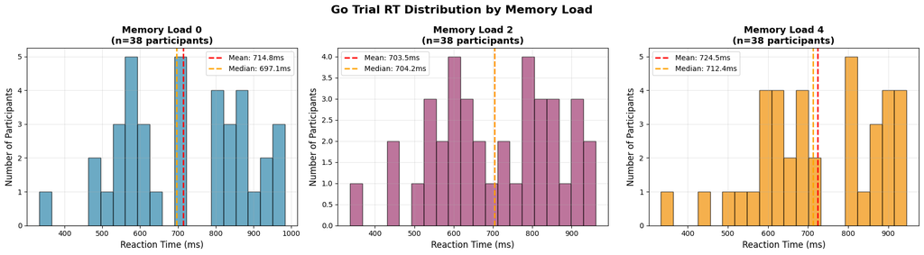

```
=== Go RT Summary Statistics ===
Memory Load 0: Mean=714.8ms, SD=166.1ms, Median=697.1ms, Range=[332.9, 983.2]ms
Memory Load 2: Mean=703.5ms, SD=158.7ms, Median=704.2ms, Range=[336.6, 961.3]ms
Memory Load 4: Mean=724.5ms, SD=152.7ms, Median=712.4ms, Range=[333.0, 945.7]ms
```

```python
# Histogram: Go RT by Memory Load
fig, axes = plt.subplots(1, 3, figsize=(18, 5))
fig.suptitle('Go Trial RT Distribution by Memory Load', fontsize=16, fontweight='bold')

colors = ['#2E86AB', '#A23B72', '#F18F01']  # Blue, Purple, Orange
conditions = [
    ('Memory Load 0', 'dual_task_go_wm0_mean_rt', colors[0]),
    ('Memory Load 2', 'dual_task_go_wm2_mean_rt', colors[1]),
    ('Memory Load 4', 'dual_task_go_wm4_mean_rt', colors[2])
]

for idx, (label, column, color) in enumerate(conditions):
    ax = axes[idx]
    data = metrics_data_wm[column].dropna()

    # Create histogram
    ax.hist(data, bins=20, alpha=0.7, color=color, edgecolor='black')

    # Add mean and median lines
    mean_val = data.mean()
    median_val = data.median()
    ax.axvline(mean_val, color='red', linestyle='--', linewidth=2,
               label=f'Mean: {mean_val:.1f}ms')
    ax.axvline(median_val, color='orange', linestyle='--', linewidth=2,
               label=f'Median: {median_val:.1f}ms')

    ax.set_xlabel('Reaction Time (ms)', fontsize=12)
    ax.set_ylabel('Number of Participants', fontsize=12)
    ax.set_title(f'{label}\n(n={len(data)} participants)', fontsize=13, fontweight='bold')
    ax.legend(fontsize=10)
    ax.grid(True, alpha=0.3)

plt.tight_layout()
plt.show()

# Print summary statistics
print("\n=== Go RT Summary Statistics ===")
for label, column, _ in conditions:
    data = metrics_data_wm[column].dropna()
    print(f"{label}: Mean={data.mean():.1f}ms, SD={data.std():.1f}ms, "
          f"Median={data.median():.1f}ms, Range=[{data.min():.1f}, {data.max():.1f}]ms")
```

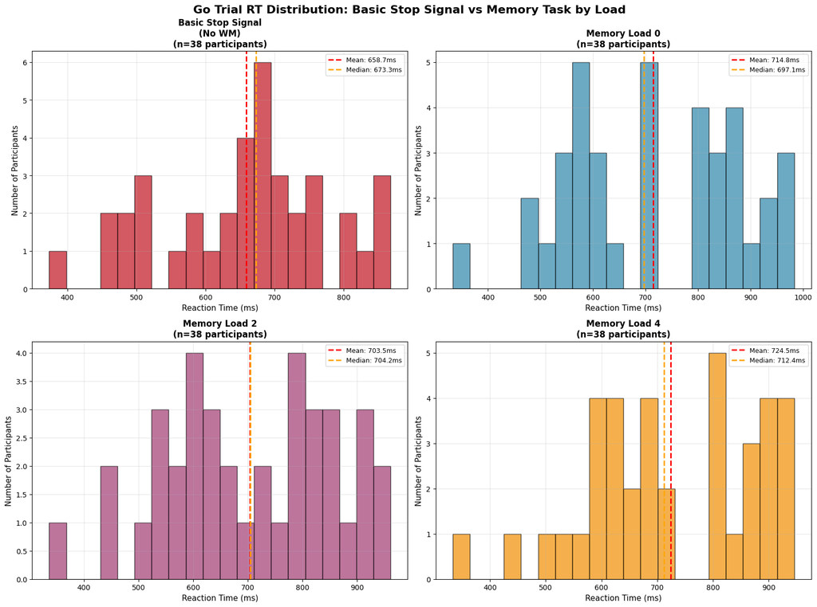

```
=== Go RT Summary Statistics: Basic Stop Signal vs Memory Task ===
Basic Stop Signal
(No WM): Mean=658.7ms, SD=122.2ms, Median=673.3ms, Range=[373.8, 868.1]ms, n=38
Memory Load 0: Mean=714.8ms, SD=166.1ms, Median=697.1ms, Range=[332.9, 983.2]ms, n=38
Memory Load 2: Mean=703.5ms, SD=158.7ms, Median=704.2ms, Range=[336.6, 961.3]ms, n=38
Memory Load 4: Mean=724.5ms, SD=152.7ms, Median=712.4ms, Range=[333.0, 945.7]ms, n=38

=== RT Cost of Memory Load ===
Memory Load 0 vs Basic Stop Signal: +56.0ms (8.5% increase)
Memory Load 2 vs Basic Stop Signal: +44.8ms (6.8% increase)
Memory Load 4 vs Basic Stop Signal: +65.8ms (10.0% increase)
```

```python
# Histogram: Compare Basic Stop Signal Go RT with WM Task Go RTs
fig, axes = plt.subplots(2, 2, figsize=(16, 12))
fig.suptitle('Go Trial RT Distribution: Basic Stop Signal vs Memory Task by Load',
             fontsize=16, fontweight='bold')

colors = ['#C1121F', '#2E86AB', '#A23B72', '#F18F01']  # Red, Blue, Purple, Orange
all_conditions = [
    ('Basic Stop Signal\n(No WM)', 'go_mean_rt', metrics_data_stop, colors[0], axes[0, 0]),
    ('Memory Load 0', 'dual_task_go_wm0_mean_rt', metrics_data_wm, colors[1], axes[0, 1]),
    ('Memory Load 2', 'dual_task_go_wm2_mean_rt', metrics_data_wm, colors[2], axes[1, 0]),
    ('Memory Load 4', 'dual_task_go_wm4_mean_rt', metrics_data_wm, colors[3], axes[1, 1])
]

rt_summary = {}

for label, column, data_source, color, ax in all_conditions:
    data = data_source[column].dropna()

    # Create histogram
    ax.hist(data, bins=20, alpha=0.7, color=color, edgecolor='black')

    # Add mean and median lines
    mean_val = data.mean()
    median_val = data.median()
    ax.axvline(mean_val, color='red', linestyle='--', linewidth=2,
               label=f'Mean: {mean_val:.1f}ms')
    ax.axvline(median_val, color='orange', linestyle='--', linewidth=2,
               label=f'Median: {median_val:.1f}ms')

    ax.set_xlabel('Reaction Time (ms)', fontsize=11)
    ax.set_ylabel('Number of Participants', fontsize=11)
    ax.set_title(f'{label}\n(n={len(data)} participants)', fontsize=12, fontweight='bold')
    ax.legend(fontsize=9)
    ax.grid(True, alpha=0.3)

    # Store summary stats
    rt_summary[label] = {
        'mean': mean_val,
        'median': median_val,
        'sd': data.std(),
        'min': data.min(),
        'max': data.max(),
        'n': len(data)
    }

plt.tight_layout()
plt.show()

# Print summary statistics
print("\n=== Go RT Summary Statistics: Basic Stop Signal vs Memory Task ===")
for label, stats in rt_summary.items():
    print(f"{label}: Mean={stats['mean']:.1f}ms, SD={stats['sd']:.1f}ms, "
          f"Median={stats['median']:.1f}ms, Range=[{stats['min']:.1f}, {stats['max']:.1f}]ms, n={stats['n']}")

# Calculate RT cost of WM load
print("\n=== RT Cost of Memory Load ===")
baseline_mean = rt_summary['Basic Stop Signal\n(No WM)']['mean']
for load in ['Memory Load 0', 'Memory Load 2', 'Memory Load 4']:
    cost = rt_summary[load]['mean'] - baseline_mean
    print(f"{load} vs Basic Stop Signal: +{cost:.1f}ms ({cost/baseline_mean*100:.1f}% increase)")
```

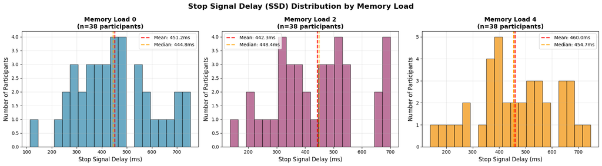

```
=== SSD Summary Statistics ===
Memory Load 0: Mean=451.2ms, SD=155.4ms, Median=444.8ms, Range=[113.2, 753.8]ms
Memory Load 2: Mean=442.3ms, SD=147.9ms, Median=448.4ms, Range=[135.8, 700.3]ms
Memory Load 4: Mean=460.0ms, SD=152.2ms, Median=454.7ms, Range=[139.2, 745.8]ms
```

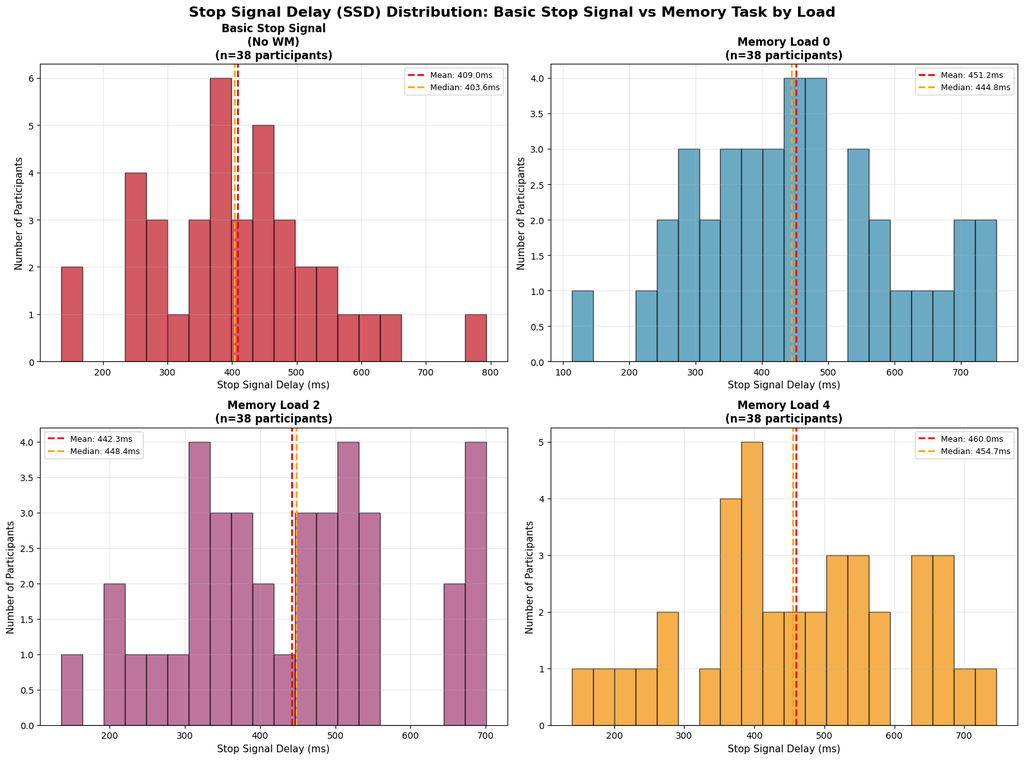

```
=== SSD Summary Statistics: Basic Stop Signal vs Memory Task ===
Basic Stop Signal
(No WM): Mean=409.0ms, SD=136.2ms, Median=403.6ms, Range=[135.8, 793.1]ms, n=38
Memory Load 0: Mean=451.2ms, SD=155.4ms, Median=444.8ms, Range=[113.2, 753.8]ms, n=38
Memory Load 2: Mean=442.3ms, SD=147.9ms, Median=448.4ms, Range=[135.8, 700.3]ms, n=38
Memory Load 4: Mean=460.0ms, SD=152.2ms, Median=454.7ms, Range=[139.2, 745.8]ms, n=38

=== SSD Difference from Basic Stop Signal ===
Memory Load 0 vs Basic Stop Signal: +42.2ms (+10.3% change)
Memory Load 2 vs Basic Stop Signal: +33.4ms (+8.2% change)
Memory Load 4 vs Basic Stop Signal: +51.0ms (+12.5% change)
```

```python
# Histogram: SSD (Stop Signal Delay) by Memory Load
fig, axes = plt.subplots(1, 3, figsize=(18, 5))
fig.suptitle('Stop Signal Delay (SSD) Distribution by Memory Load', fontsize=16, fontweight='bold')

colors = ['#2E86AB', '#A23B72', '#F18F01']  # Blue, Purple, Orange
conditions = [
    ('Memory Load 0', 'mean_SSD_wm0', colors[0]),
    ('Memory Load 2', 'mean_SSD_wm2', colors[1]),
    ('Memory Load 4', 'mean_SSD_wm4', colors[2])
]

for idx, (label, column, color) in enumerate(conditions):
    ax = axes[idx]
    data = metrics_data_wm[column].dropna()

    # Create histogram
    ax.hist(data, bins=20, alpha=0.7, color=color, edgecolor='black')

    # Add mean and median lines
    mean_val = data.mean()
    median_val = data.median()
    ax.axvline(mean_val, color='red', linestyle='--', linewidth=2,
               label=f'Mean: {mean_val:.1f}ms')
    ax.axvline(median_val, color='orange', linestyle='--', linewidth=2,
               label=f'Median: {median_val:.1f}ms')

    ax.set_xlabel('Stop Signal Delay (ms)', fontsize=12)
    ax.set_ylabel('Number of Participants', fontsize=12)
    ax.set_title(f'{label}\n(n={len(data)} participants)', fontsize=13, fontweight='bold')
    ax.legend(fontsize=10)
    ax.grid(True, alpha=0.3)

plt.tight_layout()
plt.show()

# Print summary statistics
print("\n=== SSD Summary Statistics ===")
for label, column, _ in conditions:
    data = metrics_data_wm[column].dropna()
    print(f"{label}: Mean={data.mean():.1f}ms, SD={data.std():.1f}ms, "
          f"Median={data.median():.1f}ms, Range=[{data.min():.1f}, {data.max():.1f}]ms")

# Histogram: Compare Basic Stop Signal SSD with WM Task SSD by Load
fig, axes = plt.subplots(2, 2, figsize=(16, 12))
fig.suptitle('Stop Signal Delay (SSD) Distribution: Basic Stop Signal vs Memory Task by Load',
             fontsize=16, fontweight='bold')

colors = ['#C1121F', '#2E86AB', '#A23B72', '#F18F01']  # Red, Blue, Purple, Orange
all_conditions = [
    ('Basic Stop Signal\n(No WM)', 'mean_SSD', metrics_data_stop, colors[0], axes[0, 0]),
    ('Memory Load 0', 'mean_SSD_wm0', metrics_data_wm, colors[1], axes[0, 1]),
    ('Memory Load 2', 'mean_SSD_wm2', metrics_data_wm, colors[2], axes[1, 0]),
    ('Memory Load 4', 'mean_SSD_wm4', metrics_data_wm, colors[3], axes[1, 1])
]

ssd_summary = {}

for label, column, data_source, color, ax in all_conditions:
    data = data_source[column].dropna()

    # Create histogram
    ax.hist(data, bins=20, alpha=0.7, color=color, edgecolor='black')

    # Add mean and median lines
    mean_val = data.mean()
    median_val = data.median()
    ax.axvline(mean_val, color='red', linestyle='--', linewidth=2,
               label=f'Mean: {mean_val:.1f}ms')
    ax.axvline(median_val, color='orange', linestyle='--', linewidth=2,
               label=f'Median: {median_val:.1f}ms')

    ax.set_xlabel('Stop Signal Delay (ms)', fontsize=11)
    ax.set_ylabel('Number of Participants', fontsize=11)
    ax.set_title(f'{label}\n(n={len(data)} participants)', fontsize=12, fontweight='bold')
    ax.legend(fontsize=9)
    ax.grid(True, alpha=0.3)

    # Store summary stats
    ssd_summary[label] = {
        'mean': mean_val,
        'median': median_val,
        'sd': data.std(),
        'min': data.min(),
        'max': data.max(),
        'n': len(data)
    }

plt.tight_layout()
plt.show()

# Print summary statistics
print("\n=== SSD Summary Statistics: Basic Stop Signal vs Memory Task ===")
for label, stats in ssd_summary.items():
    print(f"{label}: Mean={stats['mean']:.1f}ms, SD={stats['sd']:.1f}ms, "
          f"Median={stats['median']:.1f}ms, Range=[{stats['min']:.1f}, {stats['max']:.1f}]ms, n={stats['n']}")

# Calculate SSD difference from baseline
print("\n=== SSD Difference from Basic Stop Signal ===")
baseline_mean = ssd_summary['Basic Stop Signal\n(No WM)']['mean']
for load in ['Memory Load 0', 'Memory Load 2', 'Memory Load 4']:
    diff = ssd_summary[load]['mean'] - baseline_mean
    print(f"{load} vs Basic Stop Signal: {diff:+.1f}ms ({diff/baseline_mean*100:+.1f}% change)")
```

## 5. Simple Stop Signal vs Memory Task Go Accuracy by Load

Compare GO trial accuracy between the simple stop signal task (baseline) and the WM task across different load levels, with a horizontal line indicating the simple stop signal baseline mean.

```
Participants with complete data for both tasks: 38
```

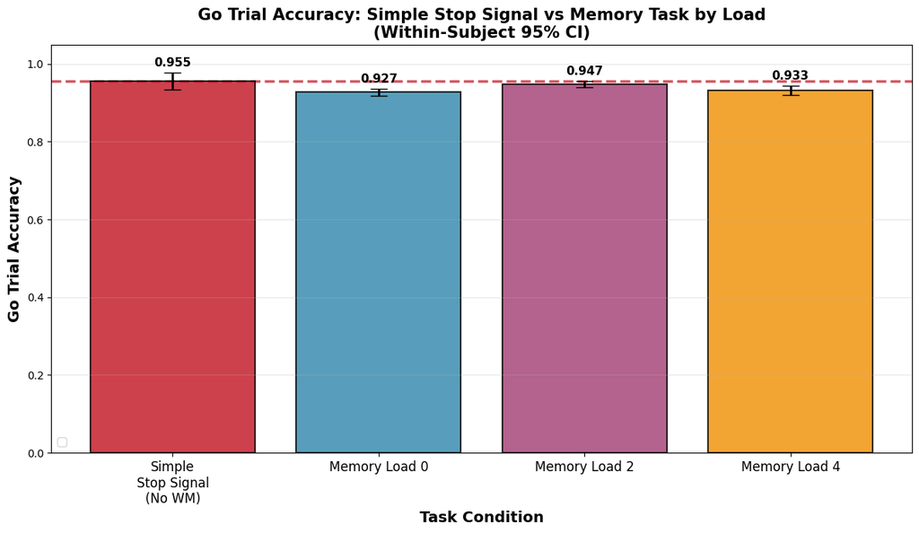

```
=== Go Trial Accuracy Summary (n=38 participants) ===

Descriptive Statistics:
  Simple Stop Signal (No WM): M=0.955 ± 0.022 (within-subject CI), SD=0.062
  Memory Load 0: M=0.927 ± 0.010 (within-subject CI), SD=0.069
  Memory Load 2: M=0.947 ± 0.008 (within-subject CI), SD=0.061
  Memory Load 4: M=0.933 ± 0.012 (within-subject CI), SD=0.072
```

```python
# Bar plot comparing Simple Stop Signal GO Accuracy with WM Task GO Accuracy by Load
fig, ax = plt.subplots(1, 1, figsize=(12, 7))

# Find participants with data for both tasks
participants_both = list(set(metrics_data_stop['prolific_id']) & set(metrics_data_wm['prolific_id']))

# Filter for participants with complete data
stop_data = metrics_data_stop[metrics_data_stop['prolific_id'].isin(participants_both)]
stop_data = stop_data.dropna(subset=['go_choice_accuracy'])

wm_data = metrics_data_wm[metrics_data_wm['prolific_id'].isin(participants_both)]
wm_data = wm_data.dropna(subset=[
    'dual_task_go_wm0_choice_accuracy', 'dual_task_go_wm2_choice_accuracy', 'dual_task_go_wm4_choice_accuracy'
])

# Get overlapping participants
common_participants = list(set(stop_data['prolific_id']) & set(wm_data['prolific_id']))
stop_data_filtered = stop_data[stop_data['prolific_id'].isin(common_participants)]
wm_data_filtered = wm_data[wm_data['prolific_id'].isin(common_participants)]

print(f"Participants with complete data for both tasks: {len(common_participants)}\n")

# Prepare data for within-subject CI calculation
# Need to align participants and create a matrix with all conditions
stop_data_filtered = stop_data_filtered.set_index('prolific_id')
wm_data_filtered = wm_data_filtered.set_index('prolific_id')

# Create data matrix for within-subject CIs (participants x conditions)
accuracy_matrix = pd.DataFrame({
    'Simple_Stop': stop_data_filtered['go_choice_accuracy'],
    'WM_Load_0': wm_data_filtered['dual_task_go_wm0_choice_accuracy'],
    'WM_Load_2': wm_data_filtered['dual_task_go_wm2_choice_accuracy'],
    'WM_Load_4': wm_data_filtered['dual_task_go_wm4_choice_accuracy']
})

# Calculate within-subject CIs
all_cis = calculate_within_subject_ci(accuracy_matrix)

# Calculate means for each condition
all_means = np.array([
    accuracy_matrix['Simple_Stop'].mean(),
    accuracy_matrix['WM_Load_0'].mean(),
    accuracy_matrix['WM_Load_2'].mean(),
    accuracy_matrix['WM_Load_4'].mean()
])

# Store simple stop mean for reference line
simple_stop_mean = all_means[0]

# Set up bar positions and colors
conditions = ['Simple\nStop Signal\n(No WM)', 'Memory Load 0', 'Memory Load 2', 'Memory Load 4']
x_pos = np.arange(len(conditions))
colors = ['#C1121F', '#2E86AB', '#A23B72', '#F18F01']  # Red for baseline, then blue/purple/orange

# Create bar plot
bars = ax.bar(x_pos, all_means, yerr=all_cis, capsize=8,
              alpha=0.8, color=colors, edgecolor='black', linewidth=1.5,
              error_kw={'linewidth': 2, 'ecolor': 'black'})

# Add horizontal line for simple stop signal mean
ax.axhline(y=simple_stop_mean, color='#C1121F', linestyle='--', linewidth=2.5,
           alpha=0.7, zorder=0)

# Formatting
ax.set_xlabel('Task Condition', fontsize=14, fontweight='bold')
ax.set_ylabel('Go Trial Accuracy', fontsize=14, fontweight='bold')
ax.set_title('Go Trial Accuracy: Simple Stop Signal vs Memory Task by Load\n(Within-Subject 95% CI)',
             fontsize=15, fontweight='bold')
ax.set_xticks(x_pos)
ax.set_xticklabels(conditions, fontsize=12)
ax.set_ylim(0, 1.05)
ax.grid(True, alpha=0.3, axis='y')
ax.legend(fontsize=11, loc='lower left')

# Add value labels on bars
for i, (bar, mean, ci) in enumerate(zip(bars, all_means, all_cis)):
    height = bar.get_height()
    ax.text(bar.get_x() + bar.get_width() / 2., height + ci + 0.01,
            f'{mean:.3f}', ha='center', va='bottom', fontsize=11, fontweight='bold')

plt.tight_layout()
plt.show()

print(f"\n=== Go Trial Accuracy Summary (n={len(common_participants)} participants) ===")
print("\nDescriptive Statistics:")
for i, condition in enumerate(conditions):
    condition_key = ['Simple_Stop', 'WM_Load_0', 'WM_Load_2', 'WM_Load_4'][i]
    print(f"  {condition.replace(chr(10), ' ')}: M={all_means[i]:.3f} ± {all_cis[i]:.3f} (within-subject CI), SD={accuracy_matrix[condition_key].std():.3f}")
```

## 6. Simple Stop Signal vs Memory Task GO RT by Load

Compare GO trial reaction times between the simple stop signal task (baseline) and the WM task across different load levels, with a horizontal line indicating the simple stop signal baseline mean.

```
Participants with complete data for both tasks: 38
```

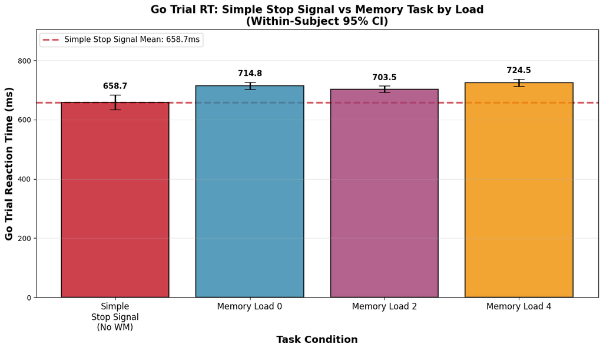

```
=== GO RT Comparison Summary (n=38 participants) ===

Simple Stop Signal (No WM): 658.7ms ± 25.0ms (within-subject 95% CI)
WM Load 0: 714.8ms ± 12.6ms (within-subject 95% CI)
WM Load 2: 703.5ms ± 10.7ms (within-subject 95% CI)
WM Load 4: 724.5ms ± 12.1ms (within-subject 95% CI)

=== RT Cost relative to Simple Stop Signal ===
WM Load 0: +56.0ms (8.5%)
WM Load 2: +44.8ms (6.8%)
WM Load 4: +65.8ms (10.0%)
```

```python
# Bar plot comparing Simple Stop Signal GO RT with WM Task GO RT by Load
fig, ax = plt.subplots(1, 1, figsize=(12, 7))

# Find participants with data for both tasks
participants_both = list(set(metrics_data_stop['prolific_id']) & set(metrics_data_wm['prolific_id']))

# Filter for participants with complete data
stop_data = metrics_data_stop[metrics_data_stop['prolific_id'].isin(participants_both)]
stop_data = stop_data.dropna(subset=['go_mean_rt'])

wm_data = metrics_data_wm[metrics_data_wm['prolific_id'].isin(participants_both)]
wm_data = wm_data.dropna(subset=[
    'dual_task_go_wm0_mean_rt', 'dual_task_go_wm2_mean_rt', 'dual_task_go_wm4_mean_rt'
])

# Get overlapping participants
common_participants = list(set(stop_data['prolific_id']) & set(wm_data['prolific_id']))
stop_data_filtered = stop_data[stop_data['prolific_id'].isin(common_participants)]
wm_data_filtered = wm_data[wm_data['prolific_id'].isin(common_participants)]

print(f"Participants with complete data for both tasks: {len(common_participants)}\n")

# Prepare data for within-subject CI calculation
# Need to align participants and create a matrix with all conditions
stop_data_filtered = stop_data_filtered.set_index('prolific_id')
wm_data_filtered = wm_data_filtered.set_index('prolific_id')

# Create data matrix for within-subject CIs (participants x conditions)
rt_matrix = pd.DataFrame({
    'Simple_Stop': stop_data_filtered['go_mean_rt'],
    'WM_Load_0': wm_data_filtered['dual_task_go_wm0_mean_rt'],
    'WM_Load_2': wm_data_filtered['dual_task_go_wm2_mean_rt'],
    'WM_Load_4': wm_data_filtered['dual_task_go_wm4_mean_rt']
})

# Calculate within-subject CIs
all_cis = calculate_within_subject_ci(rt_matrix)

# Calculate means for each condition
all_means = np.array([
    rt_matrix['Simple_Stop'].mean(),
    rt_matrix['WM_Load_0'].mean(),
    rt_matrix['WM_Load_2'].mean(),
    rt_matrix['WM_Load_4'].mean()
])

# Store simple stop mean for reference line
simple_stop_mean = all_means[0]

# Set up bar positions and colors
conditions = ['Simple\nStop Signal\n(No WM)', 'Memory Load 0', 'Memory Load 2', 'Memory Load 4']
x_pos = np.arange(len(conditions))
colors = ['#C1121F', '#2E86AB', '#A23B72', '#F18F01']  # Red for baseline, then blue/purple/orange

# all_means and all_cis are already calculated above with within-subject CIs

# Create bar plot
bars = ax.bar(x_pos, all_means, yerr=all_cis, capsize=8,
              alpha=0.8, color=colors, edgecolor='black', linewidth=1.5,
              error_kw={'linewidth': 2, 'ecolor': 'black'})

# Add horizontal line for simple stop signal mean
ax.axhline(y=simple_stop_mean, color='#C1121F', linestyle='--', linewidth=2.5,
           alpha=0.7, label=f'Simple Stop Signal Mean: {simple_stop_mean:.1f}ms', zorder=0)

# Formatting
ax.set_xlabel('Task Condition', fontsize=14, fontweight='bold')
ax.set_ylabel('Go Trial Reaction Time (ms)', fontsize=14, fontweight='bold')
ax.set_title('Go Trial RT: Simple Stop Signal vs Memory Task by Load\n(Within-Subject 95% CI)',
             fontsize=15, fontweight='bold')
ax.set_xticks(x_pos)
ax.set_xticklabels(conditions, fontsize=12)
ax.set_ylim(0, max(all_means) * 1.25)
ax.grid(True, alpha=0.3, axis='y')
ax.legend(fontsize=11, loc='upper left')

# Add value labels on bars
for i, (bar, mean, ci) in enumerate(zip(bars, all_means, all_cis)):
    height = bar.get_height()
    ax.text(bar.get_x() + bar.get_width() / 2., height + ci + 15,
            f'{mean:.1f}', ha='center', va='bottom', fontsize=11, fontweight='bold')

plt.tight_layout()
plt.show()

# Print summary statistics
print(f"\n=== GO RT Comparison Summary (n={len(common_participants)} participants) ===\n")
print(f"Simple Stop Signal (No WM): {all_means[0]:.1f}ms ± {all_cis[0]:.1f}ms (within-subject 95% CI)")
print(f"WM Load 0: {all_means[1]:.1f}ms ± {all_cis[1]:.1f}ms (within-subject 95% CI)")
print(f"WM Load 2: {all_means[2]:.1f}ms ± {all_cis[2]:.1f}ms (within-subject 95% CI)")
print(f"WM Load 4: {all_means[3]:.1f}ms ± {all_cis[3]:.1f}ms (within-subject 95% CI)")

print(f"\n=== RT Cost relative to Simple Stop Signal ===")
print(f"WM Load 0: +{all_means[1] - simple_stop_mean:.1f}ms ({(all_means[1] - simple_stop_mean)/simple_stop_mean*100:.1f}%)")
print(f"WM Load 2: +{all_means[2] - simple_stop_mean:.1f}ms ({(all_means[2] - simple_stop_mean)/simple_stop_mean*100:.1f}%)")
print(f"WM Load 4: +{all_means[3] - simple_stop_mean:.1f}ms ({(all_means[3] - simple_stop_mean)/simple_stop_mean*100:.1f}%)")
```

## 7. Probe Response RT by Memory Load

Analyze probe (memory recognition) response times across different WM load levels.

```
Participants with complete probe RT data: 38
```

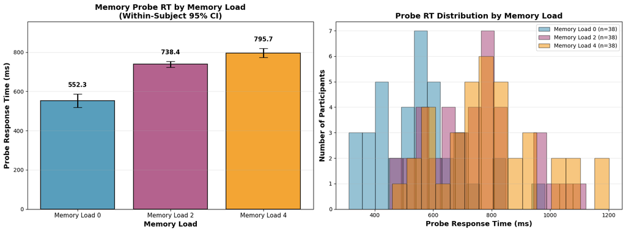

```
=== Probe RT Summary Statistics ===
Memory Load 0: 552.3ms ± 34.3ms (within-subject CI)
  SD=149.1ms, Range=[311.9, 981.9]ms, n=38
Memory Load 2: 738.4ms ± 15.6ms (within-subject CI)
  SD=159.1ms, Range=[450.7, 1122.3]ms, n=38
Memory Load 4: 795.7ms ± 23.1ms (within-subject CI)
  SD=176.3ms, Range=[459.6, 1202.0]ms, n=38

=== Probe RT Increase by Memory Load ===
Memory Load 2 vs Memory Load 0: +186.0ms (33.7% increase)
Memory Load 4 vs Memory Load 0: +243.4ms (44.1% increase)
```

```python
# Probe RT Analysis by Memory Load
fig, axes = plt.subplots(1, 2, figsize=(16, 6))

# Get participants with complete probe data
complete_probe_data = metrics_data_wm.dropna(subset=[
    'probe_wm0_mean_rt',
    'probe_wm2_mean_rt',
    'probe_wm4_mean_rt'
])

print(f"Participants with complete probe RT data: {len(complete_probe_data)}\n")

# Prepare data matrix for within-subject CI calculation
probe_rt_matrix = complete_probe_data[[
    'probe_wm0_mean_rt',
    'probe_wm2_mean_rt',
    'probe_wm4_mean_rt'
]]

# Calculate within-subject CIs
probe_rt_cis = calculate_within_subject_ci(probe_rt_matrix)

# Calculate means
probe_rt_means = np.array([
    probe_rt_matrix.iloc[:, 0].mean(),
    probe_rt_matrix.iloc[:, 1].mean(),
    probe_rt_matrix.iloc[:, 2].mean()
])

conditions = ['Memory Load 0', 'Memory Load 2', 'Memory Load 4']
x_pos = np.arange(len(conditions))
colors = ['#2E86AB', '#A23B72', '#F18F01']

# === BAR PLOT WITH WITHIN-SUBJECT CIs ===
ax1 = axes[0]
bars = ax1.bar(x_pos, probe_rt_means, yerr=probe_rt_cis, capsize=8,
               alpha=0.8, color=colors, edgecolor='black', linewidth=1.5,
               error_kw={'linewidth': 2, 'ecolor': 'black'})

ax1.set_xlabel('Memory Load', fontsize=13, fontweight='bold')
ax1.set_ylabel('Probe Response Time (ms)', fontsize=13, fontweight='bold')
ax1.set_title('Memory Probe RT by Memory Load\n(Within-Subject 95% CI)',
              fontsize=14, fontweight='bold')
ax1.set_xticks(x_pos)
ax1.set_xticklabels(conditions, fontsize=11)
ax1.set_ylim(0, max(probe_rt_means) * 1.2)
ax1.grid(True, alpha=0.3, axis='y')

# Add value labels on bars
for i, (bar, mean, ci) in enumerate(zip(bars, probe_rt_means, probe_rt_cis)):
    height = bar.get_height()
    ax1.text(bar.get_x() + bar.get_width() / 2., height + ci + 30,
             f'{mean:.1f}', ha='center', va='bottom', fontsize=11, fontweight='bold')

# === HISTOGRAM OF PROBE RTs BY LOAD ===
ax2 = axes[1]

probe_data = [
    metrics_data_wm['probe_wm0_mean_rt'].dropna(),
    metrics_data_wm['probe_wm2_mean_rt'].dropna(),
    metrics_data_wm['probe_wm4_mean_rt'].dropna()
]

# Create overlapping histograms
for i, (data, color, label) in enumerate(zip(probe_data, colors, conditions)):
    ax2.hist(data, bins=15, alpha=0.5, color=color, edgecolor='black',
             label=f'{label} (n={len(data)})', density=False)

ax2.set_xlabel('Probe Response Time (ms)', fontsize=13, fontweight='bold')
ax2.set_ylabel('Number of Participants', fontsize=13, fontweight='bold')
ax2.set_title('Probe RT Distribution by Memory Load', fontsize=14, fontweight='bold')
ax2.legend(fontsize=10)
ax2.grid(True, alpha=0.3, axis='y')

plt.tight_layout()
plt.show()

# Print summary statistics
print("=== Probe RT Summary Statistics ===")
for i, condition in enumerate(conditions):
    mean = probe_rt_means[i]
    ci = probe_rt_cis[i]
    data = probe_data[i]
    print(f"{condition}: {mean:.1f}ms ± {ci:.1f}ms (within-subject CI)")
    print(f"  SD={data.std():.1f}ms, Range=[{data.min():.1f}, {data.max():.1f}]ms, n={len(data)}")

# Calculate probe RT increase from load
print("\n=== Probe RT Increase by Memory Load ===")
baseline_probe = probe_rt_means[0]
for i in range(1, len(conditions)):
    increase = probe_rt_means[i] - baseline_probe
    percent = (increase / baseline_probe) * 100
    print(f"{conditions[i]} vs {conditions[0]}: +{increase:.1f}ms ({percent:.1f}% increase)")
```

## 8. Probe Response Accuracy by Memory Load

Analyze probe (memory recognition) accuracy across different WM load levels.

```
Participants with complete probe accuracy data: 38
```

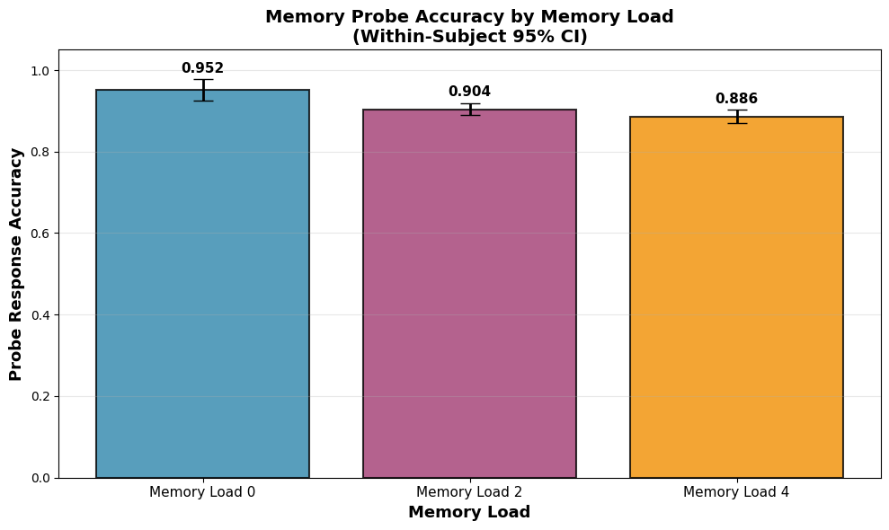

```
=== Probe Accuracy Summary Statistics ===
Memory Load 0: 0.952 ± 0.026 (within-subject CI)
  SD=0.079, Range=[0.694, 1.000], n=38
Memory Load 2: 0.904 ± 0.015 (within-subject CI)
  SD=0.090, Range=[0.674, 0.979], n=38
Memory Load 4: 0.886 ± 0.016 (within-subject CI)
  SD=0.100, Range=[0.646, 0.986], n=38

=== Probe Accuracy Decline by Memory Load ===
Memory Load 2 vs Memory Load 0: -0.048 (-5.0%)
Memory Load 4 vs Memory Load 0: -0.066 (-6.9%)
```

```python
# Probe Accuracy Analysis by Memory Load
fig, ax = plt.subplots(1, 1, figsize=(10, 6))

# Get participants with complete probe accuracy data
complete_probe_acc_data = metrics_data_wm.dropna(subset=[
    'probe_wm0_response_accuracy',
    'probe_wm2_response_accuracy',
    'probe_wm4_response_accuracy'
])

print(f"Participants with complete probe accuracy data: {len(complete_probe_acc_data)}\n")

# Prepare data matrix for within-subject CI calculation
probe_acc_matrix = complete_probe_acc_data[[
    'probe_wm0_response_accuracy',
    'probe_wm2_response_accuracy',
    'probe_wm4_response_accuracy'
]]

# Calculate within-subject CIs
probe_acc_cis = calculate_within_subject_ci(probe_acc_matrix)

# Calculate means
probe_acc_means = np.array([
    probe_acc_matrix.iloc[:, 0].mean(),
    probe_acc_matrix.iloc[:, 1].mean(),
    probe_acc_matrix.iloc[:, 2].mean()
])

conditions = ['Memory Load 0', 'Memory Load 2', 'Memory Load 4']
x_pos = np.arange(len(conditions))
colors = ['#2E86AB', '#A23B72', '#F18F01']

# === BAR PLOT WITH WITHIN-SUBJECT CIs ===
bars = ax.bar(x_pos, probe_acc_means, yerr=probe_acc_cis, capsize=8,
              alpha=0.8, color=colors, edgecolor='black', linewidth=1.5,
              error_kw={'linewidth': 2, 'ecolor': 'black'})

ax.set_xlabel('Memory Load', fontsize=13, fontweight='bold')
ax.set_ylabel('Probe Response Accuracy', fontsize=13, fontweight='bold')
ax.set_title('Memory Probe Accuracy by Memory Load\n(Within-Subject 95% CI)',
             fontsize=14, fontweight='bold')
ax.set_xticks(x_pos)
ax.set_xticklabels(conditions, fontsize=11)
ax.set_ylim(0, 1.05)
ax.grid(True, alpha=0.3, axis='y')

# Add value labels on bars
for i, (bar, mean, ci) in enumerate(zip(bars, probe_acc_means, probe_acc_cis)):
    height = bar.get_height()
    ax.text(bar.get_x() + bar.get_width() / 2., height + ci + 0.01,
            f'{mean:.3f}', ha='center', va='bottom', fontsize=11, fontweight='bold')

plt.tight_layout()
plt.show()

# Print summary statistics
print("=== Probe Accuracy Summary Statistics ===")
for i, condition in enumerate(conditions):
    mean = probe_acc_means[i]
    ci = probe_acc_cis[i]
    data = metrics_data_wm[f'probe_wm{[0,2,4][i]}_response_accuracy'].dropna()
    print(f"{condition}: {mean:.3f} ± {ci:.3f} (within-subject CI)")
    print(f"  SD={data.std():.3f}, Range=[{data.min():.3f}, {data.max():.3f}], n={len(data)}")

# Calculate accuracy decline from load
print("\n=== Probe Accuracy Decline by Memory Load ===")
baseline_acc = probe_acc_means[0]
for i in range(1, len(conditions)):
    decline = probe_acc_means[i] - baseline_acc
    percent = (decline / baseline_acc) * 100
    print(f"{conditions[i]} vs {conditions[0]}: {decline:+.3f} ({percent:+.1f}%)")
```

## 9. SSRT (Stop Signal Reaction Time) by Memory Load

```
Participants with complete SSRT data for both tasks: 38
```

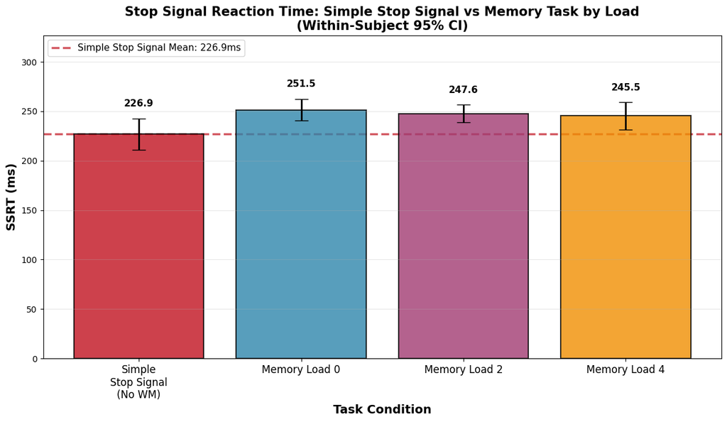

```
=== SSRT Comparison Summary (n=38 participants) ===

Simple Stop Signal (No WM): 226.9ms ± 15.9ms (within-subject 95% CI)
WM Load 0: 251.5ms ± 11.1ms (within-subject 95% CI)
WM Load 2: 247.6ms ± 8.8ms (within-subject 95% CI)
WM Load 4: 245.5ms ± 13.9ms (within-subject 95% CI)

=== SSRT Change relative to Simple Stop Signal ===
WM Load 0: +24.6ms (+10.8%)
WM Load 2: +20.7ms (+9.1%)
WM Load 4: +18.6ms (+8.2%)

=== SSRT Change across WM Loads ===
WM Load 2 vs WM Load 0: -3.8ms (-1.5%)
WM Load 4 vs WM Load 0: -6.0ms (-2.4%)
WM Load 4 vs WM Load 2: -2.1ms (-0.9%)
```

```python
# SSRT Comparison: Simple Stop Signal vs Memory Task by Load
fig, ax = plt.subplots(1, 1, figsize=(12, 7))

# Find participants with data for both tasks
participants_both = list(set(metrics_data_stop['prolific_id']) & set(metrics_data_wm['prolific_id']))

# Filter for participants with complete SSRT data
stop_data = metrics_data_stop[metrics_data_stop['prolific_id'].isin(participants_both)]
stop_data = stop_data.dropna(subset=['SSRT'])

wm_data = metrics_data_wm[metrics_data_wm['prolific_id'].isin(participants_both)]
wm_data = wm_data.dropna(subset=['SSRT_wm0', 'SSRT_wm2', 'SSRT_wm4'])

# Get overlapping participants
common_participants = list(set(stop_data['prolific_id']) & set(wm_data['prolific_id']))
stop_data_filtered = stop_data[stop_data['prolific_id'].isin(common_participants)]
wm_data_filtered = wm_data[wm_data['prolific_id'].isin(common_participants)]

print(f"Participants with complete SSRT data for both tasks: {len(common_participants)}\n")

# Prepare data for within-subject CI calculation
# Need to align participants and create a matrix with all conditions
stop_data_filtered = stop_data_filtered.set_index('prolific_id')
wm_data_filtered = wm_data_filtered.set_index('prolific_id')

# Create data matrix for within-subject CIs (participants x conditions)
ssrt_matrix = pd.DataFrame({
    'Simple_Stop': stop_data_filtered['SSRT'],
    'WM_Load_0': wm_data_filtered['SSRT_wm0'],
    'WM_Load_2': wm_data_filtered['SSRT_wm2'],
    'WM_Load_4': wm_data_filtered['SSRT_wm4']
})

# Calculate within-subject CIs
all_cis = calculate_within_subject_ci(ssrt_matrix)

# Calculate means for each condition
all_means = np.array([
    ssrt_matrix['Simple_Stop'].mean(),
    ssrt_matrix['WM_Load_0'].mean(),
    ssrt_matrix['WM_Load_2'].mean(),
    ssrt_matrix['WM_Load_4'].mean()
])

# Store simple stop mean for reference line
simple_stop_mean = all_means[0]

# Set up bar positions and colors
conditions = ['Simple\nStop Signal\n(No WM)', 'Memory Load 0', 'Memory Load 2', 'Memory Load 4']
x_pos = np.arange(len(conditions))
colors = ['#C1121F', '#2E86AB', '#A23B72', '#F18F01']  # Red for baseline, then blue/purple/orange

# all_means and all_cis are already calculated above with within-subject CIs

# Create bar plot
bars = ax.bar(x_pos, all_means, yerr=all_cis, capsize=8,
              alpha=0.8, color=colors, edgecolor='black', linewidth=1.5,
              error_kw={'linewidth': 2, 'ecolor': 'black'})

# Add horizontal line for simple stop signal mean
ax.axhline(y=simple_stop_mean, color='#C1121F', linestyle='--', linewidth=2.5,
           alpha=0.7, label=f'Simple Stop Signal Mean: {simple_stop_mean:.1f}ms', zorder=0)

# Formatting
ax.set_xlabel('Task Condition', fontsize=14, fontweight='bold')
ax.set_ylabel('SSRT (ms)', fontsize=14, fontweight='bold')
ax.set_title('Stop Signal Reaction Time: Simple Stop Signal vs Memory Task by Load\n(Within-Subject 95% CI)',
             fontsize=15, fontweight='bold')
ax.set_xticks(x_pos)
ax.set_xticklabels(conditions, fontsize=12)
ax.set_ylim(0, max(all_means) * 1.3)
ax.grid(True, alpha=0.3, axis='y')
ax.legend(fontsize=11, loc='upper left')

# Add value labels on bars
for i, (bar, mean, ci) in enumerate(zip(bars, all_means, all_cis)):
    height = bar.get_height()
    ax.text(bar.get_x() + bar.get_width() / 2., height + ci + 10,
            f'{mean:.1f}', ha='center', va='bottom', fontsize=11, fontweight='bold')

plt.tight_layout()
plt.show()

# Print summary statistics
print(f"\n=== SSRT Comparison Summary (n={len(common_participants)} participants) ===\n")
print(f"Simple Stop Signal (No WM): {all_means[0]:.1f}ms ± {all_cis[0]:.1f}ms (within-subject 95% CI)")
print(f"WM Load 0: {all_means[1]:.1f}ms ± {all_cis[1]:.1f}ms (within-subject 95% CI)")
print(f"WM Load 2: {all_means[2]:.1f}ms ± {all_cis[2]:.1f}ms (within-subject 95% CI)")
print(f"WM Load 4: {all_means[3]:.1f}ms ± {all_cis[3]:.1f}ms (within-subject 95% CI)")

print(f"\n=== SSRT Change relative to Simple Stop Signal ===")
print(f"WM Load 0: {all_means[1] - simple_stop_mean:+.1f}ms ({(all_means[1] - simple_stop_mean)/simple_stop_mean*100:+.1f}%)")
print(f"WM Load 2: {all_means[2] - simple_stop_mean:+.1f}ms ({(all_means[2] - simple_stop_mean)/simple_stop_mean*100:+.1f}%)")
print(f"WM Load 4: {all_means[3] - simple_stop_mean:+.1f}ms ({(all_means[3] - simple_stop_mean)/simple_stop_mean*100:+.1f}%)")

print(f"\n=== SSRT Change across WM Loads ===")
print(f"WM Load 2 vs WM Load 0: {all_means[2] - all_means[1]:+.1f}ms ({(all_means[2] - all_means[1])/all_means[1]*100:+.1f}%)")
print(f"WM Load 4 vs WM Load 0: {all_means[3] - all_means[1]:+.1f}ms ({(all_means[3] - all_means[1])/all_means[1]*100:+.1f}%)")
print(f"WM Load 4 vs WM Load 2: {all_means[3] - all_means[2]:+.1f}ms ({(all_means[3] - all_means[2])/all_means[2]*100:+.1f}%)")
```

## 10. ANOVA SSRT Working Memory Load effects

Run an ANOVA on the SSRT to test for effects of the memory load condition

```python
print("=== REPEATED MEASURES ANOVA: SSRT Across All Conditions ===\n")

# Find participants with complete SSRT data for both tasks
participants_both = list(set(metrics_data_stop['prolific_id']) & set(metrics_data_wm['prolific_id']))

# Filter for participants with complete SSRT data
stop_data = metrics_data_stop[metrics_data_stop['prolific_id'].isin(participants_both)]
stop_data = stop_data.dropna(subset=['SSRT'])

wm_data = metrics_data_wm[metrics_data_wm['prolific_id'].isin(participants_both)]
wm_data = wm_data.dropna(subset=['SSRT_wm0', 'SSRT_wm2', 'SSRT_wm4'])

# Get overlapping participants with complete data
common_participants = list(set(stop_data['prolific_id']) & set(wm_data['prolific_id']))
stop_data_complete = stop_data[stop_data['prolific_id'].isin(common_participants)].set_index('prolific_id')
wm_data_complete = wm_data[wm_data['prolific_id'].isin(common_participants)].set_index('prolific_id')

print(f"Participants with complete SSRT data for all conditions: {len(common_participants)}\n")

# Extract SSRT data for each condition
ssrt_simple_stop = stop_data_complete['SSRT'].values
ssrt_wm0 = wm_data_complete['SSRT_wm0'].values
ssrt_wm2 = wm_data_complete['SSRT_wm2'].values
ssrt_wm4 = wm_data_complete['SSRT_wm4'].values

# ========= ONE-WAY REPEATED MEASURES ANOVA (WM LOADS ONLY) =========
print("=== ANOVA: SSRT Across WM Loads (0, 2, 4) ===")
wm_f_stat, wm_p_value = f_oneway(ssrt_wm0, ssrt_wm2, ssrt_wm4)

print(f"One-way ANOVA (WM Load effect):")
print(f"  F-statistic: {wm_f_stat:.4f}")
print(f"  p-value: {wm_p_value:.6f}")
print(f"  Significant: {'Yes' if wm_p_value < 0.05 else 'No'} (α = 0.05)")

# Effect size (eta-squared) for WM loads
all_wm_ssrt = np.concatenate([ssrt_wm0, ssrt_wm2, ssrt_wm4])
wm_grand_mean = np.mean(all_wm_ssrt)
wm_sst = np.sum((all_wm_ssrt - wm_grand_mean)**2)
wm_ssw = (np.sum((ssrt_wm0 - np.mean(ssrt_wm0))**2) +
          np.sum((ssrt_wm2 - np.mean(ssrt_wm2))**2) +
          np.sum((ssrt_wm4 - np.mean(ssrt_wm4))**2))
wm_ssb = wm_sst - wm_ssw
wm_eta_squared = wm_ssb / wm_sst
print(f"  Effect size (η²): {wm_eta_squared:.4f}")

print(f"\nDescriptive Statistics (WM Loads):")
print(f"  WM Load 0: M={np.mean(ssrt_wm0):.1f}ms, SD={np.std(ssrt_wm0, ddof=1):.1f}ms")
print(f"  WM Load 2: M={np.mean(ssrt_wm2):.1f}ms, SD={np.std(ssrt_wm2, ddof=1):.1f}ms")
print(f"  WM Load 4: M={np.mean(ssrt_wm4):.1f}ms, SD={np.std(ssrt_wm4, ddof=1):.1f}ms")

# ========= ONE-WAY REPEATED MEASURES ANOVA (ALL CONDITIONS INCLUDING SIMPLE STOP) =========
print("\n=== ANOVA: SSRT Including Simple Stop Signal ===")
all_conditions_f_stat, all_conditions_p_value = f_oneway(
    ssrt_simple_stop, ssrt_wm0, ssrt_wm2, ssrt_wm4)

print(f"One-way ANOVA (Simple Stop + WM Loads):")
print(f"  F-statistic: {all_conditions_f_stat:.4f}")
print(f"  p-value: {all_conditions_p_value:.6f}")
print(f"  Significant: {'Yes' if all_conditions_p_value < 0.05 else 'No'} (α = 0.05)")

# Effect size (eta-squared) for all conditions
all_ssrt = np.concatenate([ssrt_simple_stop, ssrt_wm0, ssrt_wm2, ssrt_wm4])
grand_mean = np.mean(all_ssrt)
sst = np.sum((all_ssrt - grand_mean)**2)
ssw = (np.sum((ssrt_simple_stop - np.mean(ssrt_simple_stop))**2) +
       np.sum((ssrt_wm0 - np.mean(ssrt_wm0))**2) +
       np.sum((ssrt_wm2 - np.mean(ssrt_wm2))**2) +
       np.sum((ssrt_wm4 - np.mean(ssrt_wm4))**2))
ssb = sst - ssw
eta_squared = ssb / sst
print(f"  Effect size (η²): {eta_squared:.4f}")

print(f"\nDescriptive Statistics (All Conditions):")
print(f"  Simple Stop Signal: M={np.mean(ssrt_simple_stop):.1f}ms, SD={np.std(ssrt_simple_stop, ddof=1):.1f}ms")
print(f"  WM Load 0: M={np.mean(ssrt_wm0):.1f}ms, SD={np.std(ssrt_wm0, ddof=1):.1f}ms")
print(f"  WM Load 2: M={np.mean(ssrt_wm2):.1f}ms, SD={np.std(ssrt_wm2, ddof=1):.1f}ms")
print(f"  WM Load 4: M={np.mean(ssrt_wm4):.1f}ms, SD={np.std(ssrt_wm4, ddof=1):.1f}ms")

# === PAIRWISE COMPARISONS (POST-HOC) ===
print("\n=== Pairwise Comparisons (Independent t-tests) ===")
from scipy.stats import ttest_rel

# Compare Simple Stop with each WM load
print("\nSimple Stop Signal vs WM Loads:")
conditions_pairs = [
    ('Simple Stop', ssrt_simple_stop, 'Memory Load 0', ssrt_wm0),
    ('Simple Stop', ssrt_simple_stop, 'Memory Load 2', ssrt_wm2),
    ('Simple Stop', ssrt_simple_stop, 'Memory Load 4', ssrt_wm4),
]

for cond1_name, cond1_data, cond2_name, cond2_data in conditions_pairs:
    t_stat, p_val = ttest_rel(cond1_data, cond2_data)
    mean_diff = np.mean(cond2_data) - np.mean(cond1_data)
    print(f"  {cond1_name} vs {cond2_name}: t={t_stat:.3f}, p={p_val:.4f}, "
          f"Δ={mean_diff:+.1f}ms {'*' if p_val < 0.05 else ''}")

# Compare WM loads with each other
print("\nWM Load Comparisons:")
wm_pairs = [
    ('Memory Load 0', ssrt_wm0, 'Memory Load 2', ssrt_wm2),
    ('Memory Load 0', ssrt_wm0, 'Memory Load 4', ssrt_wm4),
    ('Memory Load 2', ssrt_wm2, 'Memory Load 4', ssrt_wm4),
]

for cond1_name, cond1_data, cond2_name, cond2_data in wm_pairs:
    t_stat, p_val = ttest_rel(cond1_data, cond2_data)
    mean_diff = np.mean(cond2_data) - np.mean(cond1_data)
    print(f"  {cond1_name} vs {cond2_name}: t={t_stat:.3f}, p={p_val:.4f}, "
          f"Δ={mean_diff:+.1f}ms {'*' if p_val < 0.05 else ''}")

print("\n* indicates p < 0.05")
print("\nNote: These are uncorrected p-values. For multiple comparisons, consider")
print("applying Bonferroni correction (α = 0.05/6 = 0.0083 for 6 comparisons).")

# === EFFECT SIZE FOR PAIRWISE COMPARISONS (COHEN'S D) ===
print("\n=== Effect Sizes (Cohen's d) for Key Comparisons ===")

def cohens_d(x, y):
    """Calculate Cohen's d for paired samples."""
    diff = x - y
    return np.mean(diff) / np.std(diff, ddof=1)

print("\nSimple Stop Signal vs WM Loads:")
for cond1_name, cond1_data, cond2_name, cond2_data in conditions_pairs:
    d = cohens_d(cond1_data, cond2_data)
    print(f"  {cond1_name} vs {cond2_name}: d={d:.3f} "
          f"({'small' if abs(d) < 0.5 else 'medium' if abs(d) < 0.8 else 'large'} effect)")

print("\nWM Load Comparisons:")
for cond1_name, cond1_data, cond2_name, cond2_data in wm_pairs:
    d = cohens_d(cond1_data, cond2_data)
    print(f"  {cond1_name} vs {cond2_name}: d={d:.3f} "
          f"({'small' if abs(d) < 0.5 else 'medium' if abs(d) < 0.8 else 'large'} effect)")
```

```
=== REPEATED MEASURES ANOVA: SSRT Across All Conditions ===

Participants with complete SSRT data for all conditions: 38

=== ANOVA: SSRT Across WM Loads (0, 2, 4) ===
One-way ANOVA (WM Load effect):
  F-statistic: 0.1554
  p-value: 0.856286
  Significant: No (α = 0.05)
  Effect size (η²): 0.0028

Descriptive Statistics (WM Loads):
  WM Load 0: M=251.5ms, SD=50.7ms
  WM Load 2: M=247.6ms, SD=43.4ms
  WM Load 4: M=245.5ms, SD=47.4ms

=== ANOVA: SSRT Including Simple Stop Signal ===
One-way ANOVA (Simple Stop + WM Loads):
  F-statistic: 1.8075
  p-value: 0.148317
  Significant: No (α = 0.05)
  Effect size (η²): 0.0353

Descriptive Statistics (All Conditions):
  Simple Stop Signal: M=226.9ms, SD=57.8ms
  WM Load 0: M=251.5ms, SD=50.7ms
  WM Load 2: M=247.6ms, SD=43.4ms
  WM Load 4: M=245.5ms, SD=47.4ms

=== Pairwise Comparisons (Independent t-tests) ===

Simple Stop Signal vs WM Loads:
  Simple Stop vs Memory Load 0: t=-2.600, p=0.0133, Δ=+24.6ms *
  Simple Stop vs Memory Load 2: t=-2.240, p=0.0312, Δ=+20.7ms *
  Simple Stop vs Memory Load 4: t=-1.642, p=0.1090, Δ=+18.6ms

WM Load Comparisons:
  Memory Load 0 vs Memory Load 2: t=0.619, p=0.5394, Δ=-3.8ms
  Memory Load 0 vs Memory Load 4: t=0.666, p=0.5099, Δ=-6.0ms
  Memory Load 2 vs Memory Load 4: t=0.298, p=0.7676, Δ=-2.1ms

* indicates p < 0.05

Note: These are uncorrected p-values. For multiple comparisons, consider
applying Bonferroni correction (α = 0.05/6 = 0.0083 for 6 comparisons).

=== Effect Sizes (Cohen's d) for Key Comparisons ===

Simple Stop Signal vs WM Loads:
  Simple Stop vs Memory Load 0: d=-0.422 (small effect)
  Simple Stop vs Memory Load 2: d=-0.363 (small effect)
  Simple Stop vs Memory Load 4: d=-0.266 (small effect)

WM Load Comparisons:
  Memory Load 0 vs Memory Load 2: d=0.100 (small effect)
  Memory Load 0 vs Memory Load 4: d=0.108 (small effect)
  Memory Load 2 vs Memory Load 4: d=0.048 (small effect)
```

```python
# === FORMAL REPEATED MEASURES ANOVA (2-CONDITION) ===
print("="*70)
print("=== FORMAL REPEATED MEASURES ANOVA: Simple Stop vs Dual Task ===")
print("="*70)

# Prepare data in long format for repeated measures ANOVA
# Each row is one observation (participant × condition)
anova_data = []
for i, pid in enumerate(stop_data_complete.index):
    # Simple Stop condition
    anova_data.append({
        'participant': pid,
        'condition': 'Simple Stop',
        'SSRT': ssrt_simple_stop[i]
    })
    # Dual Task condition (mean across WM loads)
    anova_data.append({
        'participant': pid,
        'condition': 'Dual Task',
        'SSRT': ssrt_dual_task_mean[i]
    })

anova_df = pd.DataFrame(anova_data)

# Compute repeated measures ANOVA using pingouin
try:
    import pingouin as pg

    # Run repeated measures ANOVA
    aov = pg.rm_anova(dv='SSRT', within='condition', subject='participant', data=anova_df, detailed=True)

    print("\nRepeated Measures ANOVA Table:")
    print(aov.to_string())
    print("\n")

    # Try to extract and summarize key statistics
    try:
        # Get column names
        cols = list(aov.columns)

        # Try to find F statistic
        if 'F' in cols:
            f_val = aov.iloc[0]['F']
        else:
            f_val = None

        # Try to find p-value
        p_val = None
        for p_col in ['p-unc', 'pval', 'p-val', 'P']:
            if p_col in cols:
                p_val = aov.iloc[0][p_col]
                break

        # Try to find degrees of freedom
        df_num, df_denom = None, None
        for df1_col, df2_col in [('ddof1', 'ddof2'), ('DF1', 'DF2'), ('DFn', 'DFd'), ('df1', 'df2')]:
            if df1_col in cols and df2_col in cols:
                df_num = aov.iloc[0][df1_col]
                df_denom = aov.iloc[0][df2_col]
                break

        # Try to find eta-squared
        eta_sq = None
        for eta_col in ['np2', 'ηp2', 'partial_eta_sq', 'eta_sq']:
            if eta_col in cols:
                eta_sq = aov.iloc[0][eta_col]
                break

        # Print summary if we have the values
        if f_val is not None and p_val is not None:
            print("--- ANOVA Summary ---")
            if df_num is not None and df_denom is not None:
                print(f"  F({df_num:.0f}, {df_denom:.0f}) = {f_val:.4f}")
            else:
                print(f"  F = {f_val:.4f}")
            print(f"  p-value = {p_val:.6f}")
            if eta_sq is not None:
                print(f"  Partial η² = {eta_sq:.4f}")
            print(f"  Significant: {'Yes' if p_val < 0.05 else 'No'} (α = 0.05)")

    except Exception as e:
        print(f"Note: Could not parse ANOVA columns automatically: {e}")
        print("Please refer to the ANOVA table above for results.")

except ImportError:
    print("\nNote: Install 'pingouin' for formal ANOVA table output:")
    print("  pip install pingouin")
    print("\nUsing manual calculation instead...")

    # Manual ANOVA calculation
    # Between-subjects effects (not of interest in RM-ANOVA)
    grand_mean = np.mean(np.concatenate([ssrt_simple_stop, ssrt_dual_task_mean]))

    # Within-subjects effects
    n = len(ssrt_simple_stop)
    k = 2  # number of conditions

    # Condition means
    mean_simple = np.mean(ssrt_simple_stop)
    mean_dual = np.mean(ssrt_dual_task_mean)

    # Sum of squares for condition
    ss_condition = n * ((mean_simple - grand_mean)**2 + (mean_dual - grand_mean)**2)
    df_condition = k - 1
    ms_condition = ss_condition / df_condition

    # Sum of squares for error (residual)
    ss_error = np.sum((ssrt_simple_stop - mean_simple)**2) + np.sum((ssrt_dual_task_mean - mean_dual)**2)
    df_error = (n - 1) * (k - 1)
    ms_error = ss_error / df_error

    # F-statistic
    f_manual = ms_condition / ms_error

    # p-value
    from scipy.stats import f as f_dist
    p_manual = 1 - f_dist.cdf(f_manual, df_condition, df_error)

    print("\nRepeated Measures ANOVA Table (Manual Calculation):")
    print(f"{'Source':<20} {'SS':>12} {'df':>6} {'MS':>12} {'F':>10} {'p-value':>10}")
    print("-" * 70)
    print(f"{'Condition':<20} {ss_condition:>12.2f} {df_condition:>6.0f} {ms_condition:>12.2f} {f_manual:>10.4f} {p_manual:>10.6f}")
    print(f"{'Error':<20} {ss_error:>12.2f} {df_error:>6.0f} {ms_error:>12.2f}")

    print(f"\n--- ANOVA Summary ---")
    print(f"  F({df_condition:.0f}, {df_error:.0f}) = {f_manual:.4f}")
    print(f"  p-value = {p_manual:.6f}")
    print(f"  Significant: {'Yes' if p_manual < 0.05 else 'No'} (α = 0.05)")

    # Partial eta-squared
    partial_eta_sq = ss_condition / (ss_condition + ss_error)
    print(f"  Partial η² = {partial_eta_sq:.4f}")

print("\n" + "="*70)
```

```
======================================================================
=== FORMAL REPEATED MEASURES ANOVA: Simple Stop vs Dual Task ===
======================================================================
```

[output not shown]

```python
# === PAIRED T-TEST: SIMPLE STOP VS DUAL TASK (COLLAPSED ACROSS WM LOADS) ===
print("\n=== ANOVA: Simple Stop Signal vs Dual Task (All WM Loads Combined) ===")

# Calculate each participant's mean SSRT across all dual task conditions
ssrt_dual_task_mean = wm_data_complete[['SSRT_wm0', 'SSRT_wm2', 'SSRT_wm4']].mean(axis=1).values

# Perform paired t-test (which is equivalent to a 2-level repeated measures ANOVA)
from scipy.stats import ttest_rel
t_stat, p_value = ttest_rel(ssrt_simple_stop, ssrt_dual_task_mean)

# Calculate F-statistic (F = t^2 for 2-level comparison)
f_stat = t_stat ** 2

print(f"Paired t-test (Simple Stop vs Dual Task):")
print(f"  t-statistic: {t_stat:.4f}")
print(f"  F-statistic: {f_stat:.4f} (F = t²)")
print(f"  p-value: {p_value:.6f}")
print(f"  Significant: {'Yes' if p_value < 0.05 else 'No'} (α = 0.05)")

# Calculate Cohen's d for paired samples
diff = ssrt_simple_stop - ssrt_dual_task_mean
cohens_d_value = np.mean(diff) / np.std(diff, ddof=1)
print(f"  Effect size (Cohen's d): {cohens_d_value:.4f} "
      f"({'small' if abs(cohens_d_value) < 0.5 else 'medium' if abs(cohens_d_value) < 0.8 else 'large'} effect)")

# Calculate eta-squared
# For 2-group comparison: η² = t² / (t² + df)
df = len(ssrt_simple_stop) - 1
eta_squared_2group = (t_stat ** 2) / (t_stat ** 2 + df)
print(f"  Effect size (η²): {eta_squared_2group:.4f}")

# Descriptive statistics
print(f"\nDescriptive Statistics:")
print(f"  Simple Stop Signal: M={np.mean(ssrt_simple_stop):.1f}ms, SD={np.std(ssrt_simple_stop, ddof=1):.1f}ms")
print(f"  Dual Task (WM 0+2+4): M={np.mean(ssrt_dual_task_mean):.1f}ms, SD={np.std(ssrt_dual_task_mean, ddof=1):.1f}ms")
print(f"  Mean Difference: {np.mean(ssrt_dual_task_mean) - np.mean(ssrt_simple_stop):+.1f}ms")

print(f"\nInterpretation:")
if p_value < 0.05:
    direction = "slower" if np.mean(ssrt_dual_task_mean) > np.mean(ssrt_simple_stop) else "faster"
    print(f"  ✓ Dual task SSRT is significantly {direction} than Simple Stop Signal")
else:
    print(f"  ✗ No significant difference between Simple Stop and Dual Task SSRT")
    print(f"    The presence of a working memory task does not significantly affect inhibitory control")
```

```
=== ANOVA: Simple Stop Signal vs Dual Task (All WM Loads Combined) ===
Paired t-test (Simple Stop vs Dual Task):
  t-statistic: -2.3487
  F-statistic: 5.5163 (F = t²)
  p-value: 0.024292
  Significant: Yes (α = 0.05)
  Effect size (Cohen's d): -0.3810 (small effect)
  Effect size (η²): 0.1297

Descriptive Statistics:
  Simple Stop Signal: M=226.9ms, SD=57.8ms
  Dual Task (WM 0+2+4): M=248.2ms, SD=39.0ms
  Mean Difference: +21.3ms

Interpretation:
  ✓ Dual task SSRT is significantly slower than Simple Stop Signal
```

## 11. Stop Signal Success Rate by Memory Load (bar)

```
=== Stop Signal Success Rate: Simple Stop vs Memory Task by Load ===

Participants with complete stop signal success rate data for all conditions: 38

Descriptive Statistics:
  Simple Stop Signal: M=0.522, SD=0.030
  WM Load 0: M=0.522, SD=0.040
  WM Load 2: M=0.527, SD=0.038
  WM Load 4: M=0.522, SD=0.039

Within-subject 95% CI half-widths:
  Simple Stop Signal: ±0.012
  WM Load 0: ±0.008
  WM Load 2: ±0.008
  WM Load 4: ±0.008
```

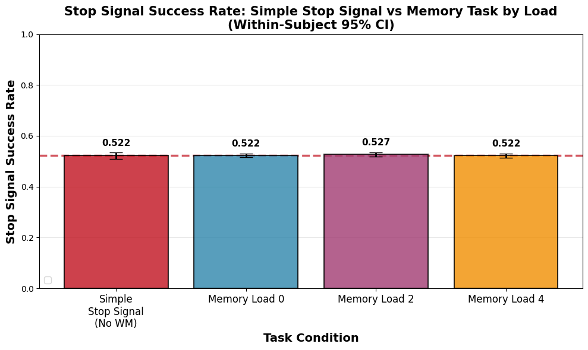

```
✓ Figure created successfully
```

```python
# Prepare data for stop signal success rate by memory load
print("=== Stop Signal Success Rate: Simple Stop vs Memory Task by Load ===\n")

# Find participants with complete stop signal success rate data for both tasks
participants_both = list(set(metrics_data_stop['prolific_id']) & set(metrics_data_wm['prolific_id']))

# Filter for participants with complete data
stop_data = metrics_data_stop[metrics_data_stop['prolific_id'].isin(participants_both)]
stop_data = stop_data.dropna(subset=['stop_inhibition_success_rate'])

wm_data = metrics_data_wm[metrics_data_wm['prolific_id'].isin(participants_both)]
wm_data = wm_data.dropna(subset=[
    'dual_task_stop_wm0_inhibition_success_rate',
    'dual_task_stop_wm2_inhibition_success_rate',
    'dual_task_stop_wm4_inhibition_success_rate'
])

# Get overlapping participants with complete data
common_participants = list(set(stop_data['prolific_id']) & set(wm_data['prolific_id']))
stop_data_complete = stop_data[stop_data['prolific_id'].isin(common_participants)].set_index('prolific_id')
wm_data_complete = wm_data[wm_data['prolific_id'].isin(common_participants)].set_index('prolific_id')

print(f"Participants with complete stop signal success rate data for all conditions: {len(common_participants)}\n")

# Create data matrix for within-subject CI calculation
# Rows = participants, Columns = conditions
stop_success_matrix = pd.DataFrame({
    'Simple_Stop': stop_data_complete['stop_inhibition_success_rate'],
    'WM_Load_0': wm_data_complete['dual_task_stop_wm0_inhibition_success_rate'],
    'WM_Load_2': wm_data_complete['dual_task_stop_wm2_inhibition_success_rate'],
    'WM_Load_4': wm_data_complete['dual_task_stop_wm4_inhibition_success_rate']
})

# Calculate within-subject confidence intervals
all_cis = calculate_within_subject_ci(stop_success_matrix)

# Calculate means for each condition
all_means = np.array([
    stop_success_matrix['Simple_Stop'].mean(),
    stop_success_matrix['WM_Load_0'].mean(),
    stop_success_matrix['WM_Load_2'].mean(),
    stop_success_matrix['WM_Load_4'].mean()
])

# Store simple stop mean for reference line
simple_stop_mean = all_means[0]

# Print descriptive statistics
print("Descriptive Statistics:")
print(f"  Simple Stop Signal: M={all_means[0]:.3f}, SD={stop_success_matrix['Simple_Stop'].std():.3f}")
print(f"  WM Load 0: M={all_means[1]:.3f}, SD={stop_success_matrix['WM_Load_0'].std():.3f}")
print(f"  WM Load 2: M={all_means[2]:.3f}, SD={stop_success_matrix['WM_Load_2'].std():.3f}")
print(f"  WM Load 4: M={all_means[3]:.3f}, SD={stop_success_matrix['WM_Load_4'].std():.3f}")
print(f"\nWithin-subject 95% CI half-widths:")
print(f"  Simple Stop Signal: ±{all_cis[0]:.3f}")
print(f"  WM Load 0: ±{all_cis[1]:.3f}")
print(f"  WM Load 2: ±{all_cis[2]:.3f}")
print(f"  WM Load 4: ±{all_cis[3]:.3f}")

# Create the figure
fig, ax = plt.subplots(figsize=(10, 6))

# Set up bar positions and colors
conditions = ['Simple\nStop Signal\n(No WM)', 'Memory Load 0', 'Memory Load 2', 'Memory Load 4']
x_pos = np.arange(len(conditions))
colors = ['#C1121F', '#2E86AB', '#A23B72', '#F18F01']  # Red for baseline, then blue/purple/orange

# Create bar plot
bars = ax.bar(x_pos, all_means, yerr=all_cis, capsize=8,
              alpha=0.8, color=colors, edgecolor='black', linewidth=1.5,
              error_kw={'linewidth': 2, 'ecolor': 'black'})

# Add horizontal line for simple stop signal mean
ax.axhline(y=simple_stop_mean, color='#C1121F', linestyle='--', linewidth=2.5,
           alpha=0.7, zorder=0)

# Customize the plot
ax.set_xlabel('Task Condition', fontsize=14, fontweight='bold')
ax.set_ylabel('Stop Signal Success Rate', fontsize=14, fontweight='bold')
ax.set_title('Stop Signal Success Rate: Simple Stop Signal vs Memory Task by Load\n(Within-Subject 95% CI)',
             fontsize=15, fontweight='bold')
ax.set_xticks(x_pos)
ax.set_xticklabels(conditions, fontsize=12)
ax.set_ylim([0, 1.0])

# Add grid for readability
ax.grid(True, alpha=0.3, axis='y')
ax.set_axisbelow(True)
ax.legend(fontsize=11, loc='lower left')

# Add value labels on bars
for i, (bar, mean, ci) in enumerate(zip(bars, all_means, all_cis)):
    height = bar.get_height()
    ax.text(bar.get_x() + bar.get_width()/2., height + ci + 0.02,
            f'{mean:.3f}',
            ha='center', va='bottom', fontsize=11, fontweight='bold')

# Add note about within-subject CIs
#ax.text(0.98, 0.02, 'Error bars show within-subject 95% CIs\n(Cousineau, 2005; Morey, 2008)',
#        transform=ax.transAxes, fontsize=9, style='italic',
#        ha='right', va='bottom', bbox=dict(boxstyle='round', facecolor='wheat', alpha=0.3))

plt.tight_layout()
plt.show()

print("\n✓ Figure created successfully")
```

## 12. BIC (Bayesian Information Criterion) Model Comparison

Bayesian model comparison for memory load effects on stop signal performance, comparing simple stop signal task vs memory task conditions (0, 2, 4 items). Uses BIC to compare models with and without condition effects.

```python
# === BIC (Bayesian Information Criterion) Model Comparison ===
# Compare models with/without condition effects on Stop Signal Success Rate and GO RT

print("="*70)
print("=== BIC MODEL COMPARISON: Memory Load Effects ===")
print("="*70)

def calculate_bic(residuals, n_params, n_obs):
    """
    Calculate BIC for a model given its residuals.
    BIC = n * ln(RSS/n) + k * ln(n)
    where RSS = sum of squared residuals, k = number of parameters, n = observations
    """
    rss = np.sum(residuals**2)
    bic = n_obs * np.log(rss / n_obs) + n_params * np.log(n_obs)
    return bic

def interpret_bic_difference(delta_bic):
    """
    Interpret BIC difference according to Kass & Raftery (1995) guidelines.
    Positive delta_bic means the second model (with effects) is better.
    """
    if delta_bic > 10:
        return "Very Strong evidence for condition effects"
    elif delta_bic > 6:
        return "Strong evidence for condition effects"
    elif delta_bic > 2:
        return "Positive evidence for condition effects"
    elif delta_bic > 0:
        return "Weak evidence for condition effects"
    elif delta_bic > -2:
        return "Weak evidence against condition effects"
    elif delta_bic > -6:
        return "Positive evidence against condition effects"
    elif delta_bic > -10:
        return "Strong evidence against condition effects"
    else:
        return "Very Strong evidence against condition effects"

# === PREPARE DATA ===
# Find participants with complete data for both tasks
participants_both = list(set(metrics_data_stop['prolific_id']) & set(metrics_data_wm['prolific_id']))

# Filter for participants with complete stop signal success rate data
stop_data = metrics_data_stop[metrics_data_stop['prolific_id'].isin(participants_both)]
stop_data = stop_data.dropna(subset=['stop_inhibition_success_rate'])

wm_data = metrics_data_wm[metrics_data_wm['prolific_id'].isin(participants_both)]
wm_data = wm_data.dropna(subset=[
    'dual_task_stop_wm0_inhibition_success_rate',
    'dual_task_stop_wm2_inhibition_success_rate',
    'dual_task_stop_wm4_inhibition_success_rate'
])

# Get overlapping participants with complete data
common_participants = list(set(stop_data['prolific_id']) & set(wm_data['prolific_id']))
stop_data_complete = stop_data[stop_data['prolific_id'].isin(common_participants)].set_index('prolific_id')
wm_data_complete = wm_data[wm_data['prolific_id'].isin(common_participants)].set_index('prolific_id')

n_participants = len(common_participants)
print(f"\nParticipants with complete data: {n_participants}")

# ===============================================
# BIC ANALYSIS 1: STOP SIGNAL SUCCESS RATE
# ===============================================
print("\n" + "="*70)
print("BIC ANALYSIS 1: STOP SIGNAL SUCCESS RATE")
print("="*70)

# Create data array: each participant's success rate across 4 conditions
# Conditions: Simple Stop, WM0, WM2, WM4
success_rate_data = np.column_stack([
    stop_data_complete['stop_inhibition_success_rate'].values,
    wm_data_complete['dual_task_stop_wm0_inhibition_success_rate'].values,
    wm_data_complete['dual_task_stop_wm2_inhibition_success_rate'].values,
    wm_data_complete['dual_task_stop_wm4_inhibition_success_rate'].values
])

n_conditions = 4
n_obs = n_participants * n_conditions

# Model 1 (Null): No condition effects - predict grand mean for all
grand_mean_sr = np.mean(success_rate_data)
residuals_null_sr = success_rate_data.flatten() - grand_mean_sr
bic_null_sr = calculate_bic(residuals_null_sr, 1, n_obs)  # 1 parameter (grand mean)

# Model 2 (Full): Condition effects - predict each condition's mean
condition_means_sr = np.mean(success_rate_data, axis=0)
residuals_full_sr = (success_rate_data - condition_means_sr).flatten()
bic_full_sr = calculate_bic(residuals_full_sr, n_conditions, n_obs)  # 4 parameters (4 condition means)

delta_bic_sr = bic_null_sr - bic_full_sr  # Positive = full model better

print(f"\nCondition means (Stop Signal Success Rate):")
print(f"  Simple Stop:  {condition_means_sr[0]:.4f}")
print(f"  WM Load 0:    {condition_means_sr[1]:.4f}")
print(f"  WM Load 2:    {condition_means_sr[2]:.4f}")
print(f"  WM Load 4:    {condition_means_sr[3]:.4f}")
print(f"  Grand Mean:   {grand_mean_sr:.4f}")

print(f"\nBIC Model Comparison:")
print(f"  Null Model (no condition effects):  BIC = {bic_null_sr:.2f}")
print(f"  Full Model (condition effects):     BIC = {bic_full_sr:.2f}")
print(f"  Delta BIC (Null - Full):            {delta_bic_sr:.2f}")
print(f"\n  Interpretation: {interpret_bic_difference(delta_bic_sr)}")

# ===============================================
# BIC ANALYSIS 2: GO TRIAL REACTION TIME
# ===============================================
print("\n" + "="*70)
print("BIC ANALYSIS 2: GO TRIAL REACTION TIME")
print("="*70)

# Get GO RT data
# Filter for participants with complete GO RT data
stop_data_rt = metrics_data_stop[metrics_data_stop['prolific_id'].isin(participants_both)]
stop_data_rt = stop_data_rt.dropna(subset=['go_mean_rt'])

wm_data_rt = metrics_data_wm[metrics_data_wm['prolific_id'].isin(participants_both)]
wm_data_rt = wm_data_rt.dropna(subset=[
    'dual_task_go_wm0_mean_rt',
    'dual_task_go_wm2_mean_rt',
    'dual_task_go_wm4_mean_rt'
])

# Get overlapping participants with complete RT data
common_participants_rt = list(set(stop_data_rt['prolific_id']) & set(wm_data_rt['prolific_id']))
stop_data_rt_complete = stop_data_rt[stop_data_rt['prolific_id'].isin(common_participants_rt)].set_index('prolific_id')
wm_data_rt_complete = wm_data_rt[wm_data_rt['prolific_id'].isin(common_participants_rt)].set_index('prolific_id')

n_participants_rt = len(common_participants_rt)
print(f"\nParticipants with complete GO RT data: {n_participants_rt}")

# Create data array
go_rt_data = np.column_stack([
    stop_data_rt_complete['go_mean_rt'].values,
    wm_data_rt_complete['dual_task_go_wm0_mean_rt'].values,
    wm_data_rt_complete['dual_task_go_wm2_mean_rt'].values,
    wm_data_rt_complete['dual_task_go_wm4_mean_rt'].values
])

n_obs_rt = n_participants_rt * n_conditions

# Model 1 (Null): No condition effects
grand_mean_rt = np.mean(go_rt_data)
residuals_null_rt = go_rt_data.flatten() - grand_mean_rt
bic_null_rt = calculate_bic(residuals_null_rt, 1, n_obs_rt)

# Model 2 (Full): Condition effects
condition_means_rt = np.mean(go_rt_data, axis=0)
residuals_full_rt = (go_rt_data - condition_means_rt).flatten()
bic_full_rt = calculate_bic(residuals_full_rt, n_conditions, n_obs_rt)

delta_bic_rt = bic_null_rt - bic_full_rt

print(f"\nCondition means (GO RT in ms):")
print(f"  Simple Stop:  {condition_means_rt[0]:.1f}")
print(f"  WM Load 0:    {condition_means_rt[1]:.1f}")
print(f"  WM Load 2:    {condition_means_rt[2]:.1f}")
print(f"  WM Load 4:    {condition_means_rt[3]:.1f}")
print(f"  Grand Mean:   {grand_mean_rt:.1f}")

print(f"\nBIC Model Comparison:")
print(f"  Null Model (no condition effects):  BIC = {bic_null_rt:.2f}")
print(f"  Full Model (condition effects):     BIC = {bic_full_rt:.2f}")
print(f"  Delta BIC (Null - Full):            {delta_bic_rt:.2f}")
print(f"\n  Interpretation: {interpret_bic_difference(delta_bic_rt)}")

# ===============================================
# BIC ANALYSIS 3: SSRT (Stop Signal Reaction Time)
# ===============================================
print("\n" + "="*70)
print("BIC ANALYSIS 3: SSRT (STOP SIGNAL REACTION TIME)")
print("="*70)

# Get SSRT data
# Filter for participants with complete SSRT data
stop_data_ssrt = metrics_data_stop[metrics_data_stop['prolific_id'].isin(participants_both)]
stop_data_ssrt = stop_data_ssrt.dropna(subset=['SSRT'])

wm_data_ssrt = metrics_data_wm[metrics_data_wm['prolific_id'].isin(participants_both)]
wm_data_ssrt = wm_data_ssrt.dropna(subset=[
    'SSRT_wm0',
    'SSRT_wm2',
    'SSRT_wm4'
])

# Get overlapping participants with complete SSRT data
common_participants_ssrt = list(set(stop_data_ssrt['prolific_id']) & set(wm_data_ssrt['prolific_id']))
stop_data_ssrt_complete = stop_data_ssrt[stop_data_ssrt['prolific_id'].isin(common_participants_ssrt)].set_index('prolific_id')
wm_data_ssrt_complete = wm_data_ssrt[wm_data_ssrt['prolific_id'].isin(common_participants_ssrt)].set_index('prolific_id')

n_participants_ssrt = len(common_participants_ssrt)
print(f"\nParticipants with complete SSRT data: {n_participants_ssrt}")

# Create data array
ssrt_data = np.column_stack([
    stop_data_ssrt_complete['SSRT'].values,
    wm_data_ssrt_complete['SSRT_wm0'].values,
    wm_data_ssrt_complete['SSRT_wm2'].values,
    wm_data_ssrt_complete['SSRT_wm4'].values
])

n_obs_ssrt = n_participants_ssrt * n_conditions

# Model 1 (Null): No condition effects
grand_mean_ssrt = np.mean(ssrt_data)
residuals_null_ssrt = ssrt_data.flatten() - grand_mean_ssrt
bic_null_ssrt = calculate_bic(residuals_null_ssrt, 1, n_obs_ssrt)

# Model 2 (Full): Condition effects
condition_means_ssrt = np.mean(ssrt_data, axis=0)
residuals_full_ssrt = (ssrt_data - condition_means_ssrt).flatten()
bic_full_ssrt = calculate_bic(residuals_full_ssrt, n_conditions, n_obs_ssrt)

delta_bic_ssrt = bic_null_ssrt - bic_full_ssrt

print(f"\nCondition means (SSRT in ms):")
print(f"  Simple Stop:  {condition_means_ssrt[0]:.1f}")
print(f"  WM Load 0:    {condition_means_ssrt[1]:.1f}")
print(f"  WM Load 2:    {condition_means_ssrt[2]:.1f}")
print(f"  WM Load 4:    {condition_means_ssrt[3]:.1f}")
print(f"  Grand Mean:   {grand_mean_ssrt:.1f}")

print(f"\nBIC Model Comparison:")
print(f"  Null Model (no condition effects):  BIC = {bic_null_ssrt:.2f}")
print(f"  Full Model (condition effects):     BIC = {bic_full_ssrt:.2f}")
print(f"  Delta BIC (Null - Full):            {delta_bic_ssrt:.2f}")
print(f"\n  Interpretation: {interpret_bic_difference(delta_bic_ssrt)}")

# ===============================================
# SUMMARY TABLE
# ===============================================
print("\n" + "="*70)
print("SUMMARY: BIC Model Comparison Results")
print("="*70)
print(f"\n{'Measure':<30} {'BIC Null':>12} {'BIC Full':>12} {'Delta BIC':>12} {'Evidence':<35}")
print("-"*101)
print(f"{'Stop Signal Success Rate':<30} {bic_null_sr:>12.2f} {bic_full_sr:>12.2f} {delta_bic_sr:>12.2f} {interpret_bic_difference(delta_bic_sr):<35}")
print(f"{'GO Reaction Time':<30} {bic_null_rt:>12.2f} {bic_full_rt:>12.2f} {delta_bic_rt:>12.2f} {interpret_bic_difference(delta_bic_rt):<35}")
print(f"{'SSRT':<30} {bic_null_ssrt:>12.2f} {bic_full_ssrt:>12.2f} {delta_bic_ssrt:>12.2f} {interpret_bic_difference(delta_bic_ssrt):<35}")

print("\n" + "="*70)
print("Note: Positive Delta BIC indicates evidence FOR condition effects")
print("      (the full model with separate condition means is better)")
print("      Interpretation based on Kass & Raftery (1995) guidelines:")
print("      0-2: Weak, 2-6: Positive, 6-10: Strong, >10: Very Strong")
print("="*70)
```

```
======================================================================
=== BIC MODEL COMPARISON: Memory Load Effects ===
======================================================================

Participants with complete data: 38

======================================================================
BIC ANALYSIS 1: STOP SIGNAL SUCCESS RATE
======================================================================

Condition means (Stop Signal Success Rate):
  Simple Stop:  0.5219
  WM Load 0:    0.5225
  WM Load 2:    0.5269
  WM Load 4:    0.5219
  Grand Mean:   0.5233

BIC Model Comparison:
  Null Model (no condition effects):  BIC = -1002.55
  Full Model (condition effects):     BIC = -987.97
  Delta BIC (Null - Full):            -14.58

  Interpretation: Very Strong evidence against condition effects

======================================================================
BIC ANALYSIS 2: GO TRIAL REACTION TIME
======================================================================

Participants with complete GO RT data: 38

Condition means (GO RT in ms):
  Simple Stop:  658.7
  WM Load 0:    714.8
  WM Load 2:    703.5
  WM Load 4:    724.5
  Grand Mean:   700.4

BIC Model Comparison:
  Null Model (no condition effects):  BIC = 1530.18
  Full Model (condition effects):     BIC = 1540.96
```

[output cut: 25 more lines]

```
SUMMARY: BIC Model Comparison Results
======================================================================

Measure                            BIC Null     BIC Full    Delta BIC Evidence
-----------------------------------------------------------------------------------------------------
Stop Signal Success Rate           -1002.55      -987.97       -14.58 Very Strong evidence against condition effects
GO Reaction Time                    1530.18      1540.96       -10.79 Very Strong evidence against condition effects
SSRT                                1196.24      1205.85        -9.60 Strong evidence against condition effects

======================================================================
Note: Positive Delta BIC indicates evidence FOR condition effects
      (the full model with separate condition means is better)
      Interpretation based on Kass & Raftery (1995) guidelines:
      0-2: Weak, 2-6: Positive, 6-10: Strong, >10: Very Strong
======================================================================
```

## 13. Pairwise T-Tests: SSRT Across Conditions

Paired t-tests comparing SSRT between each pair of conditions (Simple Stop, WM Load 0, WM Load 2, WM Load 4).

```python
# === PAIRWISE PAIRED T-TESTS: SSRT ACROSS CONDITIONS ===
from itertools import combinations
from scipy.stats import ttest_rel

print("="*80)
print("=== PAIRWISE PAIRED T-TESTS: SSRT ACROSS CONDITIONS ===")
print("="*80)

# === PREPARE DATA ===
# Find participants with complete data for both tasks
participants_both = list(set(metrics_data_stop['prolific_id']) & set(metrics_data_wm['prolific_id']))

# Filter for participants with complete SSRT data
stop_data_ssrt = metrics_data_stop[metrics_data_stop['prolific_id'].isin(participants_both)]
stop_data_ssrt = stop_data_ssrt.dropna(subset=['SSRT'])

wm_data_ssrt = metrics_data_wm[metrics_data_wm['prolific_id'].isin(participants_both)]
wm_data_ssrt = wm_data_ssrt.dropna(subset=['SSRT_wm0', 'SSRT_wm2', 'SSRT_wm4'])

# Get overlapping participants with complete SSRT data
common_participants_ssrt = list(set(stop_data_ssrt['prolific_id']) & set(wm_data_ssrt['prolific_id']))
stop_data_ssrt_complete = stop_data_ssrt[stop_data_ssrt['prolific_id'].isin(common_participants_ssrt)].set_index('prolific_id')
wm_data_ssrt_complete = wm_data_ssrt[wm_data_ssrt['prolific_id'].isin(common_participants_ssrt)].set_index('prolific_id')

# Align indices to ensure paired data
wm_data_ssrt_complete = wm_data_ssrt_complete.loc[stop_data_ssrt_complete.index]

n_participants = len(common_participants_ssrt)
print(f"\nParticipants with complete SSRT data: {n_participants}")

# Create dictionary of SSRT data by condition
ssrt_by_condition = {
    'Simple Stop': stop_data_ssrt_complete['SSRT'].values,
    'WM Load 0': wm_data_ssrt_complete['SSRT_wm0'].values,
    'WM Load 2': wm_data_ssrt_complete['SSRT_wm2'].values,
    'WM Load 4': wm_data_ssrt_complete['SSRT_wm4'].values
}

# Print descriptive statistics
print("\n" + "-"*80)
print("Descriptive Statistics (SSRT in ms):")
print("-"*80)
for condition, data in ssrt_by_condition.items():
    print(f"  {condition:<15}: M = {np.mean(data):7.2f}, SD = {np.std(data, ddof=1):7.2f}")

# === PAIRWISE T-TESTS ===
print("\n" + "="*80)
print("Pairwise Paired T-Tests")
print("="*80)

conditions = list(ssrt_by_condition.keys())
n_comparisons = len(list(combinations(conditions, 2)))
bonferroni_alpha = 0.05 / n_comparisons

print(f"\nNumber of comparisons: {n_comparisons}")
print(f"Bonferroni-corrected alpha: {bonferroni_alpha:.4f}")

print(f"\n{'Comparison':<35} {'t-stat':>10} {'p-value':>12} {'Mean Diff':>12} {'Cohen\\s d':>12} {'Sig':>8}" )
print("-"*91)

results = []
for cond1, cond2 in combinations(conditions, 2):
    data1 = ssrt_by_condition[cond1]
    data2 = ssrt_by_condition[cond2]

    # Paired t-test
    t_stat, p_value = ttest_rel(data1, data2)

    # Effect size (Cohen's d for paired samples)
    diff = data1 - data2
    mean_diff = np.mean(diff)
    cohens_d = mean_diff / np.std(diff, ddof=1)

    # Significance markers
    if p_value < 0.001:
        sig = "***"
    elif p_value < 0.01:
        sig = "**"
    elif p_value < 0.05:
        sig = "*"
    elif p_value < bonferroni_alpha:
        sig = "†"  # Bonferroni significant only
    else:
        sig = ""

    comparison = f"{cond1} vs {cond2}"
    print(f"{comparison:<35} {t_stat:>10.3f} {p_value:>12.6f} {mean_diff:>12.2f} {cohens_d:>12.3f} {sig:>8}")

    results.append({
        'comparison': comparison,
        't_stat': t_stat,
        'p_value': p_value,
        'mean_diff': mean_diff,
        'cohens_d': cohens_d,
        'sig': sig
    })

print("-"*91)
print("\nSignificance: *** p < .001, ** p < .01, * p < .05")
print(f"              † Bonferroni-corrected (p < {bonferroni_alpha:.4f})")

# === SUMMARY OF SIGNIFICANT EFFECTS ===
print("\n" + "="*80)
print("Summary of Significant Effects (uncorrected p < .05)")
print("="*80)
sig_results = [r for r in results if r['p_value'] < 0.05]
if sig_results:
    for r in sig_results:
        direction = ">" if r['mean_diff'] > 0 else "<"
        conds = r['comparison'].split(' vs ')
        print(f"  {conds[0]} {direction} {conds[1]}: t({n_participants-1}) = {r['t_stat']:.3f}, p = {r['p_value']:.4f}, d = {r['cohens_d']:.3f}")
else:
    print("  No significant pairwise differences found.")

# === BONFERRONI-CORRECTED SUMMARY ===
print("\n" + "="*80)
print(f"Summary of Bonferroni-Corrected Significant Effects (p < {bonferroni_alpha:.4f})")
print("="*80)
bonf_results = [r for r in results if r['p_value'] < bonferroni_alpha]
if bonf_results:
    for r in bonf_results:
        direction = ">" if r['mean_diff'] > 0 else "<"
        conds = r['comparison'].split(' vs ')
        print(f"  {conds[0]} {direction} {conds[1]}: t({n_participants-1}) = {r['t_stat']:.3f}, p = {r['p_value']:.4f}, d = {r['cohens_d']:.3f}")
else:
    print("  No significant pairwise differences survive Bonferroni correction.")
```

```
================================================================================
=== PAIRWISE PAIRED T-TESTS: SSRT ACROSS CONDITIONS ===
================================================================================

Participants with complete SSRT data: 38

--------------------------------------------------------------------------------
Descriptive Statistics (SSRT in ms):
--------------------------------------------------------------------------------
  Simple Stop    : M =  226.93, SD =   57.78
  WM Load 0      : M =  251.48, SD =   50.66
  WM Load 2      : M =  247.64, SD =   43.44
  WM Load 4      : M =  245.52, SD =   47.37

================================================================================
Pairwise Paired T-Tests
================================================================================

Number of comparisons: 6
Bonferroni-corrected alpha: 0.0083

Comparison                              t-stat      p-value    Mean Diff    Cohen\s d      Sig
-------------------------------------------------------------------------------------------
Simple Stop vs WM Load 0                -2.600     0.013321       -24.55       -0.422        *
Simple Stop vs WM Load 2                -2.240     0.031199       -20.71       -0.363        *
Simple Stop vs WM Load 4                -1.642     0.109036       -18.59       -0.266
WM Load 0 vs WM Load 2                   0.619     0.539431         3.84        0.100
WM Load 0 vs WM Load 4                   0.666     0.509852         5.96        0.108
WM Load 2 vs WM Load 4                   0.298     0.767636         2.12        0.048
-------------------------------------------------------------------------------------------

Significance: *** p < .001, ** p < .01, * p < .05
              † Bonferroni-corrected (p < 0.0083)

================================================================================
Summary of Significant Effects (uncorrected p < .05)
================================================================================
  Simple Stop < WM Load 0: t(37) = -2.600, p = 0.0133, d = -0.422
  Simple Stop < WM Load 2: t(37) = -2.240, p = 0.0312, d = -0.363

================================================================================
Summary of Bonferroni-Corrected Significant Effects (p < 0.0083)
================================================================================
  No significant pairwise differences survive Bonferroni correction.
```

## 14. ANOVA: Probe Accuracy by Memory Load

```python
# === ANOVA: PROBE ACCURACY BY MEMORY LOAD ===
from scipy.stats import f_oneway

print("="*70)
print("=== ANOVA: PROBE ACCURACY BY MEMORY LOAD ===")
print("="*70)

# Prepare data for ANOVA - need participants with complete data for all conditions
complete_participants_probe = metrics_data_wm.dropna(subset=[
    'probe_wm0_response_accuracy',
    'probe_wm2_response_accuracy',
    'probe_wm4_response_accuracy'
])

n_participants = len(complete_participants_probe)
print(f"\nParticipants with complete probe accuracy data for all conditions: {n_participants}")

# Probe accuracy data by load
probe_acc_wm0 = complete_participants_probe['probe_wm0_response_accuracy'].values
probe_acc_wm2 = complete_participants_probe['probe_wm2_response_accuracy'].values
probe_acc_wm4 = complete_participants_probe['probe_wm4_response_accuracy'].values

# === DESCRIPTIVE STATISTICS ===
print("\n" + "-"*70)
print("Descriptive Statistics:")
print("-"*70)
print(f"  WM Load 0: M = {np.mean(probe_acc_wm0):.4f}, SD = {np.std(probe_acc_wm0, ddof=1):.4f}")
print(f"  WM Load 2: M = {np.mean(probe_acc_wm2):.4f}, SD = {np.std(probe_acc_wm2, ddof=1):.4f}")
print(f"  WM Load 4: M = {np.mean(probe_acc_wm4):.4f}, SD = {np.std(probe_acc_wm4, ddof=1):.4f}")

# === ONE-WAY ANOVA ===
print("\n" + "="*70)
print("One-Way ANOVA Results:")
print("="*70)

f_stat, p_value = f_oneway(probe_acc_wm0, probe_acc_wm2, probe_acc_wm4)

print(f"\n  F-statistic: {f_stat:.4f}")
print(f"  p-value: {p_value:.6f}")
print(f"  Significant: {'Yes' if p_value < 0.05 else 'No'} (α = 0.05)")

# Effect size (eta-squared)
all_probe_acc = np.concatenate([probe_acc_wm0, probe_acc_wm2, probe_acc_wm4])
grand_mean = np.mean(all_probe_acc)
sst = np.sum((all_probe_acc - grand_mean)**2)
ssw = (np.sum((probe_acc_wm0 - np.mean(probe_acc_wm0))**2) +
       np.sum((probe_acc_wm2 - np.mean(probe_acc_wm2))**2) +
       np.sum((probe_acc_wm4 - np.mean(probe_acc_wm4))**2))
ssb = sst - ssw
eta_squared = ssb / sst

print(f"  Effect size (η²): {eta_squared:.4f}")

# Interpret effect size
if eta_squared < 0.01:
    effect_interp = "negligible"
elif eta_squared < 0.06:
    effect_interp = "small"
elif eta_squared < 0.14:
    effect_interp = "medium"
else:
    effect_interp = "large"
print(f"  Effect size interpretation: {effect_interp}")

# === POST-HOC PAIRWISE COMPARISONS (if significant) ===
print("\n" + "="*70)
print("Post-Hoc Pairwise Comparisons (Paired T-Tests):")
print("="*70)

from scipy.stats import ttest_rel

comparisons = [
    ('WM Load 0', 'WM Load 2', probe_acc_wm0, probe_acc_wm2),
    ('WM Load 0', 'WM Load 4', probe_acc_wm0, probe_acc_wm4),
    ('WM Load 2', 'WM Load 4', probe_acc_wm2, probe_acc_wm4)
]

n_comparisons = len(comparisons)
bonferroni_alpha = 0.05 / n_comparisons

print(f"\nBonferroni-corrected alpha: {bonferroni_alpha:.4f}")
print(f"\n{'Comparison':<25} {'t-stat':>10} {'p-value':>12} {'Mean Diff':>12} {'Cohen\\s d':>12} {'Sig':>8}")
print("-"*81)

for cond1, cond2, data1, data2 in comparisons:
    t_stat, p_val = ttest_rel(data1, data2)

    # Effect size (Cohen's d for paired samples)
    diff = data1 - data2
    mean_diff = np.mean(diff)
    cohens_d = mean_diff / np.std(diff, ddof=1)

    # Significance markers
    if p_val < bonferroni_alpha:
        sig = "**"
    elif p_val < 0.05:
        sig = "*"
    else:
        sig = ""

    comparison = f"{cond1} vs {cond2}"
    print(f"{comparison:<25} {t_stat:>10.3f} {p_val:>12.6f} {mean_diff:>12.4f} {cohens_d:>12.3f} {sig:>8}")

print("-"*81)
print(f"\nSignificance: ** Bonferroni-corrected (p < {bonferroni_alpha:.4f}), * uncorrected (p < .05)")

# === SUMMARY ===
print("\n" + "="*70)
print("Summary:")
print("="*70)
if p_value < 0.05:
    print(f"  There IS a significant effect of memory load on probe accuracy,")
    print(f"  F(2, {(n_participants-1)*2}) = {f_stat:.3f}, p = {p_value:.4f}, η² = {eta_squared:.3f} ({effect_interp})")
else:
    print(f"  There is NO significant effect of memory load on probe accuracy,")
    print(f"  F(2, {(n_participants-1)*2}) = {f_stat:.3f}, p = {p_value:.4f}, η² = {eta_squared:.3f} ({effect_interp})")
```

```
======================================================================
=== ANOVA: PROBE ACCURACY BY MEMORY LOAD ===
======================================================================

Participants with complete probe accuracy data for all conditions: 38

----------------------------------------------------------------------
Descriptive Statistics:
----------------------------------------------------------------------
  WM Load 0: M = 0.9519, SD = 0.0786
  WM Load 2: M = 0.9039, SD = 0.0897
  WM Load 4: M = 0.8861, SD = 0.1005

======================================================================
One-Way ANOVA Results:
======================================================================

  F-statistic: 5.4346
  p-value: 0.005601
  Significant: Yes (α = 0.05)
  Effect size (η²): 0.0892
  Effect size interpretation: medium

======================================================================
Post-Hoc Pairwise Comparisons (Paired T-Tests):
======================================================================

Bonferroni-corrected alpha: 0.0167

Comparison                    t-stat      p-value    Mean Diff    Cohen\s d      Sig
---------------------------------------------------------------------------------
WM Load 0 vs WM Load 2         3.027     0.004475       0.0481        0.491       **
WM Load 0 vs WM Load 4         4.052     0.000250       0.0658        0.657       **
WM Load 2 vs WM Load 4         2.639     0.012094       0.0177        0.428       **
---------------------------------------------------------------------------------

Significance: ** Bonferroni-corrected (p < 0.0167), * uncorrected (p < .05)

======================================================================
Summary:
======================================================================
  There IS a significant effect of memory load on probe accuracy,
  F(2, 74) = 5.435, p = 0.0056, η² = 0.089 (medium)
```